# Slow–Fast Hybrid Model: Linking Ising Symptoms with Precarity Dynamics

This document implements and analyzes a *slow–fast hybrid system* that links a *fast Ising symptom layer* and a slow precarity process. The overall goal is to explore how fast nonlinear symptom dynamics affect the long-term evolution of slow socioeconomic precarity.

Author

Affiliation

Kyuri Park

Computational Science Lab

Published

November 23, 2025

We are trying to study a slow-fast hybrid system that couples:

- a fast 0/1 Ising-like symptom layer with mean activity $m(t) \in [0,1]$ and,
- a slow precarity process $P(t)$ driven by mean reversion and symptom feedback.

Time-scale separation lets us “freeze” $P$ and characterize the fast layer at quasi-equilibrium, then use those frozen statistics to drive the slow SDE for $P$.

The reasoning is:

1. The fast variables, symptoms $S$, evolve rapidly under the influence of slowly changing $P$.
2. Over a short interval where $P$ barely moves, $S$ relaxes to its stationary distribution for that fixed $P$.
3. As $P$ drifts slowly, the stationary distribution of $S$ changes gradually.
4. The fast system *tracks* that changing equilibrium –> hence “quasi-equilibrium”.

**Goal**: Replace a coupled fast-slow system by a reduced model where the slow variable $P(t)$ evolves using equilibrium summaries of the fast system at the current $P$.

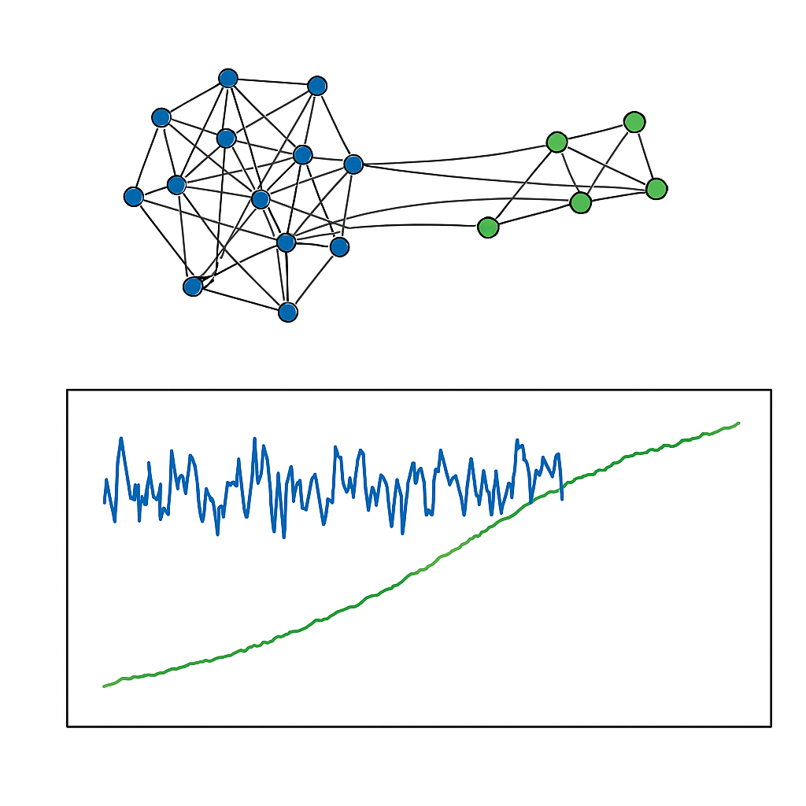

## 0) Setup

Prepares the environment – loads libraries and defines helper utilities like `inv_logit`.

```r
library(dplyr)
library(purrr)
library(tidyr)
library(ggplot2)
library(splines)
library(tibble)
library(mclust)
suppressPackageStartupMessages(library(diptest))
library(future)
library(furrr)
library(patchwork)
library(IsingFit)
library(purrr)

# plotting theme
theme_set(theme_minimal(base_size = 12))

# logit fnc
inv_logit <- function(z) 1/(1+exp(-z))
```

## 1) Fast layer: 0/1 Ising model

The fast subsystem models binary symptom activation, where each symptom $s_i(t) \in \{0,1\}$ updates according to:

$$P(s_i = 1 \mid s_{-i}, P)
= \operatorname{logit}^{-1}\!\big(\beta[J \bar{s}_{-i} + \theta_0 + \gamma_P P]\big),$$

where:

- $J$: coupling strength between symptoms (mutual reinforcement),
- $\beta$: inverse temperature (controls determinism of updates),
- $\theta_0 + \gamma_P P$: external field (threshold) shifted by precarity $P$.

The function `simulate_fast_toy()` runs a sequential update scheme (Glauber dynamics) where, at each sweep, all symptoms are updated once on average. After a short burn-in, it records the *mean activity*
$$m_t = \frac{1}{n}\sum_i s_i(t),$$
which approximates the fast layer’s stationary response at fixed precarity $P$.

This layer captures fast symptom fluctuations that quickly equilibrate given the current slow precarity state.

```r
#' Simulate fast-layer (symptom network) dynamics at fixed precarity level
#'
#' This function simulates the **fast 0/1 Ising-like symptom network**
#' given a fixed precarity level \eqn{P}. Each node (symptom) can be inactive (0)
#' or active (1), and updates its state stochastically according to
#' the logistic activation probability determined by its neighbors’ activity
#' and the external field shifted by precarity.
#'
#' The simulation uses **Glauber dynamics** (random sequential single-node updates)
#' and records the mean symptom activation after a burn-in period.
#' The result represents the empirical mean activity trajectory
#' for the fast layer conditioned on \eqn{P}.
#'
#' @param P Numeric scalar. Fixed precarity level for which to simulate
#'        the fast layer (external field shift).
#' @param n Integer. Number of symptom nodes in the network (default = 200).
#' @param steps Integer. Number of *sweeps* to perform (default = 800).
#'        Each sweep performs approximately \code{n} random node updates.
#' @param beta Numeric. Inverse temperature controlling stochasticity
#'        (higher = more deterministic; default = 1.2).
#' @param J Numeric. Coupling strength between symptoms
#'        (controls reinforcement among active nodes; default = 9.5).
#' @param theta0 Numeric. Baseline activation threshold (default = 0.0).
#' @param gammaP Numeric. Scaling factor for precarity’s influence on
#'        thresholds (default = 2.0). Effective threshold becomes
#'        \eqn{\theta_P = \theta_0 + \gamma_P P}.
#' @param burn Integer. Number of initial sweeps to discard as burn-in
#'        before collecting samples (default = 200).
#' @param thin Integer. Thinning interval (record every \code{thin}-th sweep
#'        after burn-in to reduce autocorrelation; default = 2).
#' @param seed Optional integer. Random seed for reproducibility (default = NULL).
#'
#' @details
#' The model updates nodes sequentially using the following rule:
#' \deqn{
#'   P(s_i = 1 \mid s_{-i}, P)
#'     = \operatorname{logit}^{-1}\!\big( \beta[J \bar{s}_{-i} + \theta_0 + \gamma_P P] \big),
#' }
#' where \eqn{\bar{s}_{-i}} is the mean activity of all other nodes.
#'
#' The mean activation at sweep \eqn{t} is stored as
#' \eqn{m_t = \frac{1}{n}\sum_i s_i(t)}.
#' After burn-in and thinning, the function returns the vector
#' \eqn{(m_{t_1}, m_{t_2}, \dots)} representing the stationary trajectory
#' of average symptom activation for the given precarity level.
#'
#' @return A numeric vector of length approximately \code{(steps - burn)/thin},
#'         giving the mean symptom activation per recorded sweep (values in [0,1]).
#'
#' @examples
#' set.seed(123)
#' out <- simulate_fast_toy(P = 0.5)
#' plot(out, type = "l", ylab = "Mean symptom activity", xlab = "Sweep index")
#'
#' hist(out, breaks = 20, main = "Distribution of symptom activation at fixed P")
#'
#' @seealso \code{\link{frozen_stats}}, \code{\link{branches_from_fixed_points}}
#'
#' @export
simulate_fast_toy <- function(P, n = 200, steps = 800, beta = 1.2, J = 9.5,
                              theta0 = 0.0, gammaP = 2.0, burn = 200, thin = 2, seed = NULL){
  if (!is.null(seed)) set.seed(seed)

  # initialize symptom states (mostly inactive)
  s <- rbinom(n, 1, 0.10)

  # external field shifted by precarity
  theta_P <- theta0 + gammaP * P

  # storage vector for mean activity
  rec <- numeric(0)

  # main simulation loop (steps = number of sweeps)
  for (sw in seq_len(steps)){
    for (u in seq_len(n)){
      # randomly select one symptom node
      i <- sample.int(n, 1)

      # compute mean neighbor activation
      m_nb <- (sum(s) - s[i]) / (n - 1)

      # compute activation potential
      eta  <- J * m_nb + theta_P

      # logistic activation probability
      p_i  <- inv_logit(beta * eta)

      # stochastic update of node i
      s[i] <- rbinom(1, 1, pmin(pmax(p_i, 1e-6), 1 - 1e-6))
    }

    # after burn-in, record every `thin`-th sweep
    if (sw > burn && (sw - burn) %% thin == 0)
      rec <- c(rec, mean(s))
  }

  # return mean activation trajectory
  rec
}
```

## 2) Mean-field branches and frozen statistics

If we ignore fluctuations and look for the average equilibrium $m^*$ at fixed $P$, the mean-field equation is:

$$m^* = \frac{1}{1 + \exp[-\beta(J m^* + \theta_0 + \gamma_P P)]}.$$

- If this equation has one solution → the fast system is **unimodal**.
- If it has three solutions (two stable, one unstable) → the system is **bistable**.

We check stability via $f'(m;P)<0)$.

### Functions:

- `fixed_points_for_P(P)` finds equilibria $m^*$ for each fixed $P$, and checks their stability ($df/dm < 0$).
- `branches_from_fixed_points(P-grid)` constructs the *low* and *high* stable branches ($m_\text{low}(P)$, $m_\text{high}(P)$) and flags whether each $P$ is unimodal or bistable.
- `frozen_stats()` runs actual fast-layer simulations for each $P$, measuring switching rates between states (only when bistable):
  $$k_\uparrow(P) = \text{rate of low→high transitions}, \quad
  k_\downarrow(P) = \text{rate of high→low transitions}.$$
  Rates are computed from *dwell times* on high/low segments. Then, we smooth these discrete lookups with monotone spline to obtain continuous functions. The output is a table connecting each $P$ with its frozen fast-layer statistics:
  $$\{P,\, m_\text{low},\, m_\text{high},\, k_\uparrow,\, k_\downarrow\}.$$

These data later serve as **lookup functions** for the slow simulation.

```r
#' Compute fixed points and bistable branches of the fast Ising layer
#'
#' These helper functions find the **mean-field equilibria** (fixed points) of the
#' fast 0/1 Ising-like subsystem for different precarity levels \eqn{P},
#' classify their stability, and (optionally) estimate empirical switching rates
#' between low- and high-activity states via direct simulation.
#'
#' @details
#' The mean-field fixed point equation is:
#' \deqn{
#'   f(m; P) = \sigma(\beta[Jm + \theta_0 + \gamma_P P]) - m = 0,
#' }
#' where \eqn{\sigma(x)} is the logistic function.
#' Stable equilibria satisfy \eqn{f'(m; P) < 0}.
#'
#' The functions are structured hierarchically:
#' \itemize{
#'   \item \code{fixed_points_for_P()} finds all equilibria \eqn{m^\*} and their stability for a single \eqn{P}.
#'   \item \code{branches_from_fixed_points()} loops over a grid of \eqn{P} values and constructs
#'         the low/high equilibrium branches.
#'   \item \code{frozen_stats()} extends this by empirically estimating
#'         upward/downward switching rates \eqn{k_{\uparrow}(P), k_{\downarrow}(P)}
#'         from fast-layer simulations.
#' }
#'
#' @param P Numeric scalar. Fixed precarity level (for \code{fixed_points_for_P()})
#'           or vector of precarity levels (for \code{branches_from_fixed_points()} / \code{frozen_stats()}).
#' @param P_grid Numeric vector of precarity levels (for branch/summary functions).
#' @param beta Numeric. Inverse temperature controlling stochasticity (default = 1.2).
#' @param J Numeric. Coupling strength between symptoms (default = 9.5).
#' @param theta0 Numeric. Baseline activation threshold (default = 0.0).
#' @param gammaP Numeric. Strength of precarity's effect on thresholds (default = 2.0).
#' @param steps Integer. Number of sweeps for fast-layer simulation (default = 800).
#' @param thin Integer. Thinning interval for fast-layer simulation (default = 2).
#' @param seed Integer. Random seed (default = 1).
#'
#' @return
#' \describe{
#'   \item{\code{fixed_points_for_P()}}{Data frame with columns:
#'     \code{m} (equilibrium value) and \code{stable} (TRUE/FALSE).}
#'   \item{\code{branches_from_fixed_points()}}{Data frame of \eqn{P},
#'     \code{m_low}, \code{m_high}, and \code{unimodal} flags.}
#'   \item{\code{frozen_stats()}}{Same as above, with estimated
#'     switching rates \code{k_up} and \code{k_down}.}
#' }
#'
#' @examples
#' # 1) Single-P equilibrium analysis
#' fixed_points_for_P(P = 0)
#'
#' # 2) Full branch structure
#' P_grid <- seq(-2, 2, length.out = 41)
#' br <- branches_from_fixed_points(P_grid)
#' plot(br$P, br$m_low, type='l'); lines(br$P, br$m_high, col='red')
#'
#' # 3) Extended frozen stats with empirical rates
#' frozen_stats(seq(-1, 1, length.out=11))
#'
#' @export
fixed_points_for_P <- function(P, beta=1.2, J=9.5, theta0=0, gammaP=2.0){

  # Define the mean-field self-consistency function f(m) = logistic(...) - m
  f  <- function(m)
    1/(1 + exp(-beta * (J * m + theta0 + gammaP * P))) - m

  # Derivative of f(m) with respect to m, used for stability check
  df <- function(m){
    p <- 1/(1 + exp(-beta * (J * m + theta0 + gammaP * P)))
    beta * J * p * (1 - p) - 1
  }

  # Evaluate f(m) over a dense grid to detect zero crossings
  grid <- seq(0, 1, length.out = 501)
  y <- f(grid)
  cand <- which(diff(sign(y)) != 0)  # indices where f changes sign (potential roots)

  # Refine each candidate interval using uniroot() for precise root location
  roots <- c()
  for (k in cand){
    r <- try(uniroot(f, c(grid[k], grid[k+1]))$root, silent = TRUE)
    if (!inherits(r, "try-error")) roots <- c(roots, r)
  }

  # Clean up duplicates and sort the unique roots
  roots <- sort(unique(round(roots, 6)))

  # Return a data frame of roots and stability classification (df<0 ⇒ stable)
  data.frame(m = roots, stable = (df(roots) < 0))
}


#' @rdname fixed_points_for_P
#' @export
branches_from_fixed_points <- function(P_grid, beta=1.2, J=9.5, theta0=0, gammaP=2.0){

  # Apply fixed_points_for_P() to each P in the grid, combine results
  do.call(rbind, lapply(P_grid, function(P){
    fps <- fixed_points_for_P(P, beta, J, theta0, gammaP)  # equilibria for this P

    # keep only stable equilibria
    stab <- fps[fps$stable, , drop = FALSE]

    # summarize for this P
    if (nrow(stab) == 0) {
      data.frame(P = P, unimodal = NA, m_low = NA_real_, m_high = NA_real_)
    } else if (nrow(stab) == 1) {
      if (stab$m[1] < 0.5) {
        data.frame(P = P, unimodal = TRUE, m_low = stab$m[1], m_high = NA_real_)
      } else {
        data.frame(P = P, unimodal = TRUE, m_low = NA_real_, m_high = stab$m[1])
      }
    } else {
      data.frame(P = P, unimodal = FALSE,
                 m_low = min(stab$m), m_high = max(stab$m))
    }
  }))
}


#' @rdname fixed_points_for_P
#' @export
frozen_stats <- function(P_grid, steps = 800, thin = 2, seed = 1,
                         beta=1.2, J=9.5, theta0=0, gammaP=2.0){

  # Compute static bifurcation branches across P
  br <- branches_from_fixed_points(P_grid, beta, J, theta0, gammaP)

  # Initialize placeholders for empirical switching rates
  br$k_up   <- 0
  br$k_down <- 0

  # Identify which P values are bistable
  bi_idx <- which(br$unimodal == FALSE)

  # Loop over bistable P values to estimate k_up and k_down via simulation
  if (length(bi_idx)){
    for (ii in bi_idx){
      P <- br$P[ii]

      # Simulate fast-layer dynamics for fixed P
      x <- tryCatch(
        simulate_fast_toy(P, steps = steps, thin = thin,
                          seed = seed + round(1000 * P),
                          beta = beta, J = J, theta0 = theta0, gammaP = gammaP),
        error = function(e) NA_real_
      )

      # proceed only if we have enough valid samples
      if (length(x) >= 30 && all(is.finite(x))){

        # threshold halfway between low and high equilibria
        thr <- mean(c(br$m_low[ii], br$m_high[ii]))

        # label time points as low (0) or high (1) branch
        labs <- as.integer(x >= thr)

        # run-length encoding of branch occupancy to get dwell times
        r <- rle(labs)
        low_dw  <- r$lengths[r$values == 0]
        high_dw <- r$lengths[r$values == 1]

        # upward and downward transition rates = inverse mean dwell time
        br$k_up[ii]   <- if (length(low_dw))  1 / mean(low_dw)  else 0
        br$k_down[ii] <- if (length(high_dw)) 1 / mean(high_dw) else 0
      }
    }
  }

  # Return as tibble for easy plotting and manipulation
  tibble::as_tibble(br)
}
```

## 3) Slow drift for the precarity process $P(t)$

The slow subsystem describes how precarity evolves under two forces:

1. Mean reversion: precarity tends to drift toward a baseline $P^*$;
2. Symptom feedback: when symptoms are high, precarity increases further.

The drift function is:

$$\frac{dP}{dt}
= -\kappa(P - P^*)
+ \beta_m (m - m^*)
+ c_0.$$

where:

| Symbol | Meaning |
| --- | --- |
| $\kappa$ | mean reversion rate (pulls (P) back toward ($P^*$)) |
| $\beta_m$ | feedback from symptom activity (pushes (P) up when symptoms exceed ($m^*$)) |
| $m^*$ | neutral symptom baseline |
| $c_0$ | small constant bias term (a tiny global bias; default = 0) |

Implemented as `f_drift(P, m, pars)`, this provides the deterministic part of the slow SDE (stochastic differential equation).

```r
#' Compute deterministic drift for the slow precarity layer
#'
#' Defines the deterministic (mean) drift term for the slow precarity
#' variable \eqn{P(t)} in the hybrid slow–fast system. The drift captures
#' both *mean reversion* toward a baseline level and *feedback* from the
#' fast symptom subsystem.
#'
#' @details
#' The drift function implements a linear mean-reverting process with
#' an additive push from the average symptom level \eqn{m(t)}:
#' \deqn{
#'   \frac{dP}{dt} = -\kappa \big(P - P^\ast\big)
#'                    + \beta_m \big(m - m^\ast\big)
#'                    + c_0,
#' }
#' where:
#' \itemize{
#'   \item \eqn{\kappa} controls the strength of mean reversion toward
#'         the baseline precarity level \eqn{P^\ast};
#'   \item \eqn{\beta_m} governs how deviations in symptom activity
#'         (\eqn{m - m^\ast}) affect precarity;
#'   \item \eqn{c_0} is a constant offset term (global drift bias).
#' }
#'
#' Conceptually, this defines the *slow feedback loop* in the hybrid model:
#'
#' \preformatted{
#'      +---------------------+
#'      |                     |
#'      |     symptoms (m)    |
#'      |          ↑          |
#'      |          |          |
#'      |          | (Γ, B)   |
#'      ↓          |          ↓
#'   precarity (P) -----> thresholds -----> symptoms
#'          ↑                (fast)
#'          |
#'   mean reversion (κ)
#' }
#'
#' The fast symptom layer depends on current \eqn{P},
#' while the slow precarity layer evolves based on the mean symptom
#' activity \eqn{m}, with separate timescales for the two subsystems.
#'
#' @param P Numeric scalar. Current precarity value.
#' @param m Numeric scalar. Current mean symptom activation (0–1).
#' @param pars Optional list of parameter overrides. Recognized names:
#'   \describe{
#'     \item{\code{kappa}}{Mean reversion strength (default 0.25).}
#'     \item{\code{beta_m}}{Symptom feedback strength (default 1.0).}
#'     \item{\code{P_star}}{Baseline precarity level \eqn{P^\ast} (default 0.0).}
#'     \item{\code{m_star}}{Baseline symptom level \eqn{m^\ast} (default 0.30).}
#'     \item{\code{c0}}{Constant drift offset (default 0.0).}
#'   }
#'
#' @return
#' Numeric value giving the deterministic drift \eqn{f_{\text{drift}}(P, m)}
#' — the expected change in precarity per unit time before stochastic noise.
#'
#' @examples
#' # Default drift (mean reversion + symptom feedback)
#' f_drift(P = 0.5, m = 0.8)
#'
#' # Weaker mean reversion, stronger feedback
#' f_drift(P = 0.5, m = 0.8, pars = list(kappa = 0.1, beta_m = 2.0))
#'
#' # Visualize drift direction for a range of P and m
#' curve(f_drift(P = x, m = 0.3), from = -1, to = 1,
#'       ylab = "f_drift(P, m)", xlab = "P")
#'
#' @export
f_drift <- function(P, m, pars = NULL) {
  defaults <- list(
    kappa = 0.25,  # mean reversion toward P*
    beta_m = 1.0,  # symptom push strength
    P_star = 0.0,  # target P (center)
    m_star = 0.30, # symptom baseline
    c0 = 0.0       # offset
  )
  if (!is.null(pars)) defaults[names(pars)] <- pars
  with(defaults, {
    -kappa * (P - P_star) + beta_m * (m - m_star) + c0
  })
}
```

## 4) Reduced models for the slow dynamics

### 4.1 Unimodal reduction

Assumes the fast subsystem has a single equilibrium branch $m(P)$. When the fast layer is unimodal, we plug ($m(P)$) directly into the slow SDE:
$$dP_t = f_{\text{drift}}(P_t, m(P_t)),dt + \sigma,dW_t.$$

Here ($m(P)$) is the smoothed branch (from freezing). `simulate_P_unimodal(...)` integrates this with Euler–Maruyama.

### 4.2 Hybrid reduction

In the bistable regime, the fast subsystem is represented by a *two-state process*:

$$X_t \in \{0,1\} \quad\text{(low/high symptom regime)},$$

with switching probabilities:

$$\Pr[X_{t+dt}=1|X_t=0] = k_\uparrow(P_t)\,dt, \quad
\Pr[X_{t+dt}=0|X_t=1] = k_\downarrow(P_t)\,dt.$$

**Why the $dt$ in the switching probability?**

That’s how *continuous-time Poisson processes* are simulated: the chance of one jump in a tiny interval is “rate × length of the interval” $(k,dt)$.

The slow SDE becomes
$$dP_t = f_{\text{drift}}\big(P_t, m_{X_t}(P_t)\big),dt + \sigma,dW_t,$$
where $m_0=m_{\text{low}}$ and $m_1=m_{\text{high}}$. Implemented in `simulate_P_hybrid(...)`.

```r
#' Simulate slow precarity dynamics under reduced slow–fast coupling
#'
#' These functions simulate the **slow precarity process** \eqn{P(t)} using
#' the reduced dynamics derived from the fast–slow hybrid model. The fast
#' Ising symptom layer is replaced by its *average response* (expected
#' symptom level \eqn{m(P)}) or by a *bistable hybrid approximation* with
#' stochastic regime switching.
#'
#' @details
#' ### 1) Unimodal model
#' The \code{simulate_P_unimodal()} function assumes the fast layer has a
#' single smooth equilibrium branch \eqn{m(P)}. Precarity evolves according
#' to a stochastic differential equation (SDE):
#' \deqn{
#'   dP_t = f_{\text{drift}}(P_t, m(P_t))\,dt
#'          + \sigma\, dW_t,
#' }
#' where \eqn{f_{\text{drift}}} is defined by \code{\link{f_drift}} and
#' \eqn{W_t} is standard Brownian motion.
#'
#' ### 2) Hybrid (bistable) model
#' The \code{simulate_P_hybrid()} function represents the fast layer as a
#' **two-state metastable process** (low vs. high symptom regimes) that
#' switches randomly with rates \eqn{k_\uparrow(P)} and
#' \eqn{k_\downarrow(P)}:
#' \deqn{
#'   \Pr[X_{t+dt}=1|X_t=0] \approx k_\uparrow(P_t)\,dt, \qquad
#'   \Pr[X_{t+dt}=0|X_t=1] \approx k_\downarrow(P_t)\,dt.
#' }
#'
#' The slow variable then evolves as:
#' \deqn{
#'   dP_t = f_{\text{drift}}(P_t, m_{X_t}(P_t))\,dt
#'          + \sigma\, dW_t,
#' }
#' where \eqn{m_0(P)} and \eqn{m_1(P)} correspond to the low and high
#' symptom branches of the fast subsystem.
#'
#' These reduced models allow studying how slow dynamics behave once
#' the fast subsystem has been averaged out or represented by a
#' coarse-grained metastate.
#'
#' @param P0 Numeric. Initial value of precarity \eqn{P(0)}.
#' @param T Numeric. Total simulation duration (default = 2000).
#' @param dt Numeric. Integration time step (default = 0.2).
#' @param sigma Numeric. Noise amplitude (standard deviation of Gaussian shocks).
#' @param m_fun Function returning mean symptom activation given \eqn{P}.
#'              Used only in \code{simulate_P_unimodal()}.
#' @param drift_pars List of parameters passed to \code{\link{f_drift}}.
#' @param m_low,m_high Functions giving mean symptom levels for the
#'        low and high metastable branches, respectively.
#' @param k_up,k_down Functions giving upward and downward switching
#'        rates as a function of \eqn{P}.
#' @param x0 Integer (0 or 1). Initial metastate for the hybrid model
#'           (0 = low-symptom regime, 1 = high-symptom regime).
#'
#' @return
#' \describe{
#'   \item{\code{simulate_P_unimodal()}}{A \code{ts} time series of precarity values.}
#'   \item{\code{simulate_P_hybrid()}}{A list with elements:
#'     \describe{
#'       \item{\code{P}}{A \code{ts} time series of precarity.}
#'       \item{\code{X}}{Integer vector (0/1) of metastate over time.}
#'     }}
#' }
#'
#' @examples
#' # Example unimodal simulation (smooth mean response)
#' m_fun <- function(P) inv_logit(2*P)
#' pu <- simulate_P_unimodal(P0 = 0, m_fun = m_fun)
#' plot(pu, main = "P dynamics (unimodal fast layer)")
#'
#' # Example hybrid simulation (bistable fast layer)
#' m_low_fun  <- function(P) 0.1 + 0.05*P
#' m_high_fun <- function(P) 0.8 + 0.02*P
#' k_up_fun   <- function(P) exp(-5*(P+1))
#' k_down_fun <- function(P) exp(-5*(-P+1))
#' ph <- simulate_P_hybrid(P0 = 0, m_low = m_low_fun, m_high = m_high_fun,
#'                         k_up = k_up_fun, k_down = k_down_fun)
#' plot(ph$P, main = "P dynamics (hybrid switching model)")
#' lines(ph$X, col = "red", lwd = 2)
#'
#' @seealso \code{\link{f_drift}}, \code{\link{simulate_fast_toy}},
#'          \code{\link{frozen_stats}}, \code{\link{branches_from_fixed_points}}
#'
#' @export
simulate_P_unimodal <- function(P0 = 0, T = 2000, dt = 0.2, sigma = 0.03,
                                m_fun = NULL, drift_pars = NULL){
  n <- ceiling(T/dt)
  P <- numeric(n); P[1] <- P0
  for (t in 2:n){
    m <- m_fun(P[t-1])
    d <- f_drift(P[t-1], m, pars = drift_pars)
    P[t] <- P[t-1] + d*dt + sigma*sqrt(dt)*rnorm(1)
  }
  ts(P, deltat = dt)
}

#' @rdname simulate_P_unimodal
#' @export
simulate_P_hybrid <- function(P0 = 0, T = 2000, dt = 0.2, sigma = 0.03,
                              m_low = NULL, m_high = NULL,
                              k_up = NULL, k_down = NULL,
                              drift_pars = NULL, x0 = 0L){
  n <- ceiling(T/dt)
  P <- numeric(n); P[1] <- P0
  X <- integer(n); X[1] <- x0
  for (t in 2:n){
    Pup <- P[t-1]
    if (X[t-1] == 0L && runif(1) < k_up(Pup)*dt)   X[t] <- 1L
    else if (X[t-1] == 1L && runif(1) < k_down(Pup)*dt) X[t] <- 0L
    else X[t] <- X[t-1]
    m <- if (X[t] == 0L) m_low(Pup) else m_high(Pup)
    d <- f_drift(Pup, m, pars = drift_pars)
    P[t] <- Pup + d*dt + sigma*sqrt(dt)*rnorm(1)
  }
  list(P = ts(P, deltat = dt), X = X)
}
```

## 5) Putting it together: Demo run (produces visible switching)

1. Choose a broad (P)-grid and stronger $J,\beta$ to widen the bistable region.

**Explain Bistability Range**

#### 1) The mean-field equation governing the average activation $m$ at fixed $P$ is:

$$m = \sigma\!\big(\beta [Jm + \theta_0 + \gamma_P P]\big),$$

where:

- $\sigma(x) = \frac{1}{1 + e^{-x}}$ is the logistic (sigmoid) function,
- $J$ is the internal coupling between symptoms,
- $\beta$ is the inverse temperature (controls stochasticity),
- $\gamma_P$ is how strongly the slow variable $P$ shifts the fast system’s thresholds.

#### 2) Expressing equilibria as a function of $P$

We can invert the mean-field equation to express the equilibrium curve $P(m)$:

$$\boxed{
P(m) = \frac{1}{\gamma_P}
\left[
\frac{1}{\beta} \ln\!\frac{m}{1 - m} - Jm - \theta_0
\right].
}$$

This defines, for each $m$, which value of $P$ makes the system stationary.

#### 3) Fold (bistability boundary) condition

The system is bistable when $P(m)$ becomes *S-shaped* — that is, when it folds back on itself. The folds occur where the slope $dP/dm = 0$:

$$\frac{dP}{dm} = \frac{1}{\gamma_P}
\left[
\frac{1}{\beta m(1 - m)} - J
\right] = 0.$$

Solving for $m$ gives the two fold points (low and high branches):

$$\boxed{
m(1 - m) = \frac{1}{\beta J}.
}$$

These exist only when $\beta J > 4$, which is the classical *bistability condition* for the mean-field Ising model.

#### 4) Fold coordinates in $(m, P)$-space

Plugging the fold $m$-values back into $P(m)$ gives:

$$\boxed{
P_{\text{fold}}(m)
= \frac{1}{\gamma_P}
\left[
\frac{1}{\beta}\ln\!\frac{m}{1 - m}
- Jm - \theta_0
\right].
}$$

These two points $P_{\text{fold}}^{\text{low}}$ and $P_{\text{fold}}^{\text{high}}$ define the *edges of the bistable region* in the slow variable $P$.

#### 5) How each parameter affects the bistable region

##### (a) Coupling $J$

- Appears both inside the sigmoid and in the fold condition $m(1 - m) = 1 / (\beta J)$.
- Increasing $J$ *steepens* the feedback and creates bistability.
- It also widens the separation between the low and high $m$ branches.

##### (b) Inverse temperature $\beta$

- Multiplies all input terms in the sigmoid, scaling its slope.
- Larger $β$ reduces noise, sharpening the transitions.
- The product $βJ$ determines whether bistability is possible:
  $$βJ > 4 \;\Rightarrow\; \text{bistability}.$$

##### (c) Coupling strength to precarity $γ_P$

- Enters *linearly* in the denominator of $P(m)$.
- It *rescales the horizontal axis* (P-axis) of the bifurcation diagram.

From the equation for the folds:

$$\Delta P_{\text{bistable}}
= P_{\text{fold}}^{\text{high}} - P_{\text{fold}}^{\text{low}}
= \frac{1}{\gamma_P}
\big(\Delta h_{\text{fold}}\big),$$
where $\Delta h_{\text{fold}}$ is the width of the bistable region in the internal field $h = Jm + \theta_0$.

Thus:
$$\boxed{
\text{Width in } P \;\propto\; \frac{1}{\gamma_P}.
}$$

So: - Increasing $γ_P$ **compresses** the bistable region along the $P$-axis. - Decreasing $γ_P$ **stretches** it (wider range of $P$ produces bistability).

This is a scaling effect — $γ_P$ does *not* create bistability, it only changes the *P-range* over which it’s observed.

6. Why we choose large $J$, $β$, and moderate $γ_P$
- We pick *large $J$ and $β$* to make the fast system strongly nonlinear and ensure a clear S-shaped curve.
- We pick *moderate $γ_P$* so that the bistable region spans a visible portion of the $P$-axis (not too compressed).
2. Call `frozen_stats(P_grid, ...)` to obtain $m_{\text{low/high}}$ and $k_{\uparrow/\downarrow}$.
3. Build the spline functions with `mk_fun(...)`.

**Smooth Interpolation**

A *cubic Hermite spline* is a smooth interpolation that connects each pair of points with a cubic polynomial whose slope matches at both ends. The monotone Hermite version we use (`monoH.FC`) ensures the curve doesn’t wiggle or overshoot. We interpolate frozen statistics like mean symptom activity and switching rates, which should change smoothly and monotonically with precarity.

4. Pick drift parameters $\kappa,\beta_m,P^*,m^*$ and noise $\sigma$.
5. Run both:
   - `simulate_P_unimodal(...)` (uses $m_{\text{low}}(P)$ in the demo),
   - `simulate_P_hybrid(...)` (uses low/high branches + switching rates).
6. Plot and compare: unimodal settles near one ($P$); hybrid shows plateau-and-jump dynamics due to regime switches.

```r
#' ## 5) Demo run: Reduced slow simulations with visible switching
#'
#' This section runs two reduced models of the slow precarity dynamics:
#' \itemize{
#'   \item \strong{Unimodal:} fast layer has a single stable equilibrium
#'         \eqn{m(P)} — precarity evolves smoothly around one attractor.
#'   \item \strong{Hybrid:} fast layer is bistable — it can switch stochastically
#'         between low- and high-symptom branches (\eqn{m_{\text{low}}, m_{\text{high}}}),
#'         producing intermittent jumps in precarity.
#' }
#'
#' The simulation uses parameters chosen to widen the bistable region
#' (stronger coupling and higher sensitivity), making regime switching
#' clearly visible.
#'
#' @details
#' Steps:
#' \enumerate{
#'   \item Generate grid of precarity values \eqn{P} for the fast-layer freezing.
#'   \item Compute frozen statistics (mean activity and switching rates).
#'   \item Smooth those discrete results into continuous functions
#'         (\code{m_low_fun}, \code{m_high_fun}, \code{k_up_fun}, \code{k_down_fun}).
#'   \item Simulate the reduced slow dynamics under both unimodal and hybrid
#'         approximations.
#' }
#'
#' @seealso \code{\link{simulate_P_unimodal}}, \code{\link{simulate_P_hybrid}},
#'          \code{\link{frozen_stats}}, \code{\link{f_drift}}
#'
#' @examples
#' # Produces visible regime switching in P(t)
#' source("frozen_stats.R")
#' source("simulate_P_models.R")
#'
#' # Run this chunk to compare unimodal vs hybrid dynamics
#' # plot(pu, main = "Unimodal SDE")
#' # plot(ph$P, main = "Hybrid SDE with switching")
#'
#' @export
set.seed(1)  # reproducibility

# ---------------------------------------------------------------------
# 1) Compute frozen fast-layer statistics
# ---------------------------------------------------------------------

# Define grid of precarity values (broader range to capture bistability)
P_grid <- seq(-4, 4, length.out = 41)

# Estimate fast-layer equilibrium means and switching rates across P
stats_df <- frozen_stats(
  P_grid,
  steps  = 800,
  thin   = 2,
  seed   = 1,
  beta   = 1.5,   # stronger inverse temperature → more deterministic switching
  J      = 11,    # stronger coupling → clearer bistability
  theta0 = 0,
  gammaP = 2.5    # stronger P → threshold influence
)

# ---------------------------------------------------------------------
# 2) Helper to build smooth interpolation functions from frozen data
# ---------------------------------------------------------------------
#' @description Internal utility: Converts discrete (x,y) lookup data
#'              into a continuous spline-based function for use in simulation.
mk_fun <- function(x, y, fallback = 0){
  keep <- is.finite(x) & is.finite(y)
  if (sum(keep) < 3)
    return(function(P) rep(fallback, length(P)))  # fallback if insufficient data
  sf <- stats::splinefun(x[keep], y[keep], method = "monoH.FC")
  function(P) as.numeric(sf(P))                   # return interpolator function
}

# ---------------------------------------------------------------------
# 3) Construct smooth functions for mean branches and switching rates
# ---------------------------------------------------------------------

m_low_fun   <- mk_fun(stats_df$P, stats_df$m_low, 0)  # low-symptom mean
m_high_fun  <- mk_fun(stats_df$P,
                      ifelse(is.na(stats_df$m_high), stats_df$m_low, stats_df$m_high), 0)  # high-symptom mean
k_up_fun    <- mk_fun(stats_df$P, stats_df$k_up, 0)    # upward switching rate
k_down_fun  <- mk_fun(stats_df$P, stats_df$k_down, 0)  # downward switching rate

# ---------------------------------------------------------------------
# 4) Define parameters for slow drift function
# ---------------------------------------------------------------------

pars <- list(
  kappa   = 0.1,   # weaker mean reversion (so P can wander)
  beta_m  = 1.0,   # symptom → precarity feedback
  P_star  = 0.0,   # central baseline precarity
  m_star  = 0.30   # neutral symptom baseline
)
sigma <- 0.05       # noise amplitude (larger = stronger random shocks)
P0    <- -2.0       # initial P near bistable region

# ---------------------------------------------------------------------
# 5) Simulate slow-layer dynamics: unimodal vs hybrid
# ---------------------------------------------------------------------

# (a) Unimodal model: single smooth equilibrium
pu <- simulate_P_unimodal(
  P0 = P0, T = 1200, dt = 0.2, sigma = sigma,
  m_fun = m_low_fun, drift_pars = pars
)

# (b) Hybrid model: stochastic switching between low/high equilibria
ph <- simulate_P_hybrid(
  P0 = P0, T = 1200, dt = 0.2, sigma = sigma,
  m_low = m_low_fun, m_high = m_high_fun,
  k_up = k_up_fun, k_down = k_down_fun,
  drift_pars = pars, x0 = 0L  # start in low-symptom regime
)

# ---------------------------------------------------------------------
# 6) Plot trajectories for visual comparison
# ---------------------------------------------------------------------

# par(mfrow = c(2,1), mar = c(3,4,2,1))
# plot(pu,  main = "P-only SDE (unimodal fast layer)", ylab = "Precarity P")
# plot(ph$P, main = "Hybrid switching model (bistable fast layer)", ylab = "Precarity P")


# # ---------------------------------------------------------------------
# # Animated comparison of P trajectories: Unimodal vs Hybrid
# # ---------------------------------------------------------------------
# library(ggplot2)
# library(gganimate)
# library(dplyr)
# library(tidyr)
#
# # Prepare the data in long (tidy) format
# df_anim <- tibble(
#   time = time(pu),
#   P_unimodal = as.numeric(pu),
#   P_hybrid   = as.numeric(ph$P)
# ) %>%
#   pivot_longer(cols = c(P_unimodal, P_hybrid),
#                names_to = "model", values_to = "P") %>%
#   mutate(model = recode(model,
#                         P_unimodal = "P-only SDE (unimodal fast layer)",
#                         P_hybrid   = "Hybrid switching model (bistable fast layer)"))
#
# # Create the base ggplot
# p_anim <- ggplot(df_anim, aes(x = time, y = P, color = model)) +
#   geom_line(linewidth = 1) +
#   geom_point(size = 2) +
#   labs(
#     title = "Slow–Fast Dynamics over Time",
#     subtitle = "Comparing unimodal vs. hybrid (bistable) precarity evolution",
#     x = "Time", y = "Precarity (P)",
#     color = "Model"
#   ) +
#   theme_minimal(base_size = 14) +
#   theme(legend.position = "top") +
#   scale_color_brewer(palette = "Dark2") +
#   # Animate with gganimate
#   transition_reveal(time)
#
# # Render the animation
# animate(p_anim, nframes = 300, fps = 20, width = 800, height = 450, renderer = gifski_renderer())
# anim_save("P_trajectory_comparison.gif", animation = last_animation())
#
#
#
# p_anim_facet <- ggplot(df_anim, aes(x = time, y = P)) +
#   geom_line(linewidth = 1.2, color = "#0072B2") +
#   geom_point(size = 2, color = "#D55E00") +
#   facet_wrap(~ model, ncol = 1, scales = "free_y") +
#   labs(
#     title = "Precarity Trajectories under Unimodal vs. Hybrid Dynamics",
#     x = "Time", y = "Precarity (P)"
#   ) +
#   theme_minimal(base_size = 14) +
#   theme(strip.text = element_text(face = "bold", size = 13)) +
#   transition_reveal(time)
#
# animate(p_anim_facet, nframes = 300, fps = 30, width = 700, height = 600, renderer = gifski_renderer())
# anim_save("P_trajectory_faceted.gif", animation = last_animation())
```

[figure not shown]

**Results:**

- Unimodal $P_t$: converges to a single equilibrium (around $P \approx -3$).
- Hybrid $P_t$: exhibits *bistable switching* — rare transitions between low-precarity (~−3) and high-precarity (~+6) states.

These two plateaus correspond to the stable equilibria of the full slow–fast system.

**Results in Detail**

##### Recall the slow–fast setup

Our hybrid model couples:

- a *fast system* — the symptom Ising layer $(m_t)$, and
- a *slow system* — the precarity variable $(P_t)$.

The equations are:

$$m = \text{mean activation of fast layer (depends on P)}, \\
dP_t = f_{\text{drift}}(P_t, m_t),dt + \sigma,dW_t,$$

with drift:

$$f_{\text{drift}}(P, m)
= -\kappa (P - P^*) + \beta_m (m - m^*).$$

Here:

- $-\kappa (P - P^*)$ = mean reversion → pulls P back toward its “normal” baseline $P^*$ (say 0),
- $\beta_m (m - m^*)$ = push from the fast layer → if symptoms rise above baseline $m^*$, they increase precarity.

###### The unimodal case

In the unimodal model, $m_t$ is a *single-valued, smooth function* of $P_t$:

$$m_t = m_{\text{low}}(P_t).$$

There’s only one stable equilibrium $m^*(P))$for every $P$. So the slow equation reduces to:

$$\frac{dP_t}{dt} = -\kappa (P_t - P^*) + \beta_m [m_{\text{low}}(P_t) - m^*].$$

At equilibrium, the drift term = 0:

$$-\kappa (P^* - P_{\text{eq}}) + \beta_m [m_{\text{low}}(P_{\text{eq}}) - m^*] = 0.$$

Solving this gives a *single fixed point* $P_{\text{eq}}$.

That’s why your *unimodal* trajectory settles around *one stable level* (≈ −3).

This single value is where the two forces balance:

- mean reversion pulls $P$ toward baseline,
- fast-layer feedback (via $m_{\text{low}})$ pushes it up or down slightly, until they exactly cancel.

So $P_t$ hovers stochastically around that equilibrium due to noise $σ$, but never switches regime — there’s only one basin of attraction.

##### The *hybrid (bistable)* case

In the hybrid model, the fast system can be in two distinct steady states for a given $P$:

$$m_t \in { m_{\text{low}}(P),; m_{\text{high}}(P) }.$$

This makes the drift term *state-dependent*:

$$\frac{dP_t}{dt} =
-\kappa (P_t - P^*) + \beta_m [m_X(P_t) - m^*],$$
where $X_t$ = 0 (low branch) or 1 (high branch).

Each branch has its own effective equilibrium for $P$:
$$f_{\text{drift}}(P, m_{\text{low}}(P)) = 0
\quad\text{and}\quad
f_{\text{drift}}(P, m_{\text{high}}(P)) = 0.$$

Those are the two stable fixed points you see in your simulation:

- one around $P \approx -3$,
- the other around $P \approx +6$.

##### Why these particular numbers

Let’s plug in the drift terms conceptually.

At equilibrium:
$$0 = -\kappa (P_{\text{eq}} - P^*) + \beta_m (m - m^*).$$

→ Solve for $P_{\text{eq}}$:

$$P_{\text{eq}} = P^* + \frac{\beta_m}{\kappa}(m - m^*).$$

Now, in your parameter settings:

- $P^* = 0$,
- $\kappa = 0.1$,
- $\beta_m = 1.0$,
- $m^* = 0.3$,
- and $m_{\text{low}} \approx 0.0$, $m_{\text{high}} \approx 1.0$ (from the Ising layer).

Then:

$$\begin{aligned}
P_{\text{low}} &\approx 0 + \frac{1}{0.1}(0.0 - 0.3) = -3,\
P_{\text{high}} &\approx 0 + \frac{1}{0.1}(1.0 - 0.3) = +7.
\end{aligned}$$

Exactly the two plateaus you observe:

- one near −3, one near +6–7.

So those aren’t random — they’re predicted directly by your drift equation and parameter values.

##### Dynamics: how the switching happens

When the fast layer (symptoms) flips between its two stable branches:

- $m_t$ jumps from $m_{\text{low}}$ to $m_{\text{high}}$,
- the drift term $f_{\text{drift}}$ suddenly changes sign,
- $P_t$ then moves toward the *other* equilibrium $P_{\text{high}}$.

Because the switching rates $k_\uparrow(P)$ and $k_\downarrow(P)$ are small, these transitions are *rare and abrupt* — long stable periods (plateaus) separated by quick jumps.

##### Interpretation (empirical / conceptual)

| Model | Mechanism | Interpretation |
| --- | --- | --- |
| **Unimodal** | One stable equilibrium (low precarity) | System self-regulates: stressors fade, symptoms stabilize. |
| **Hybrid** | Two stable equilibria, rare transitions | System can lock into two regimes — “asymptomatic” vs “symptomatic”. |

## 6) Bifurcation plot (for intuition)

Finally, we plot the bifurcation structure of the fast Ising layer:

$$m^* = f(m^*, P),$$
showing both stable branches (solid) and the unstable middle branch (dashed).

The S-shaped curve reveals:

- Grey band: bistable region (two stable equilibria co-exist).
- Left/right folds: tipping points where one equilibrium disappears.
- Dashed middle: unstable equilibrium separating the two basins.

This diagram explains why the hybrid model shows switching and hysteresis: the fast layer’s bistable response to $P$ creates two attractors in the slow process.

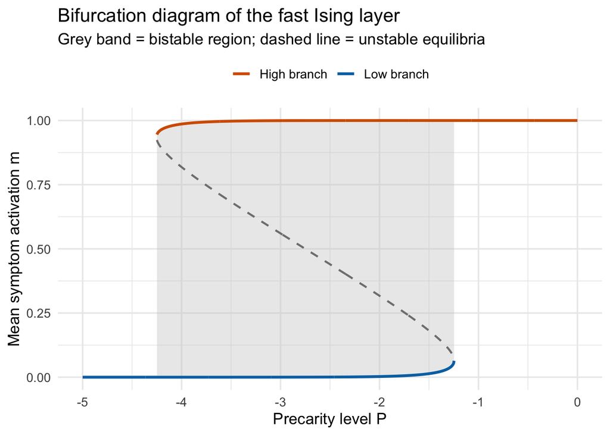

```r
plot_bifurcation <- function(beta = 1.5, J = 11, theta0 = 0, gammaP = 2.0,
                             P_grid = seq(-5, 0, length.out = 1000)) {
  # --- Step 1: compute all equilibria (stable + unstable) ----------------
  all_pts <- purrr::map_dfr(P_grid, function(P) {
    fps <- fixed_points_for_P(P, beta, J, theta0, gammaP)
    if (nrow(fps) == 0) return(NULL)
    data.frame(P = P, m = fps$m, stable = fps$stable)
  })

  # --- Step 2: extract only stable branches to get low/high for shading --
  br <- branches_from_fixed_points(P_grid, beta, J, theta0, gammaP)

  # determine end of bistability (for cleaner ribbon)
  P_cut <- max(br$P[br$unimodal == FALSE], na.rm = TRUE)
  br$m_low[br$P > P_cut] <- NA  # stop low branch continuation

  # --- Step 3: plotting ---------------------------------------------------
  ggplot() +
    # (a) bistable grey band
    geom_ribbon(
      data = dplyr::filter(br, !unimodal),
      aes(x = P, ymin = m_low, ymax = m_high),
      fill = "grey80", alpha = 0.4
    ) +
    # (b) unstable (dashed) branch
    geom_line(
      data = subset(all_pts, stable == FALSE),
      aes(x = P, y = m),
      linetype = "dashed", color = "grey50", linewidth = 0.8
    ) +
    # (c) stable branches
    geom_line(
      data = subset(all_pts, stable == TRUE & m < 0.5),
      aes(x = P, y = m, color = "Low branch"), linewidth = 1.1
    ) +
    geom_line(
      data = subset(all_pts, stable == TRUE & m >= 0.5),
      aes(x = P, y = m, color = "High branch"), linewidth = 1.1
    ) +
    # --- Step 4: styling ---------------------------------------------------
    scale_color_manual(values = c("Low branch" = "#0072B2",
                                  "High branch" = "#D55E00")) +
    labs(
      title = "Bifurcation diagram of the fast Ising layer",
      subtitle = "Grey band = bistable region; dashed line = unstable equilibria",
      x = "Precarity level P",
      y = "Mean symptom activation m",
      color = NULL
    ) +
    theme_minimal(base_size = 13) +
    theme(legend.position = "top")
}

plot_bifurcation()
```

## 7) Extension: Apply Slow–Fast Framework to HELIUS Data

We now use the [HELIUS dataset](https://heliusstudy.nl/en/) to calibrate the model for two groups: *Dutch* and *Non-dutch*.

**Goal.** Use one shared fast symptom layer (Ising mean‑field) and shared cross‑domain links (Γ:P→S, B:S→P), while allowing slow precarity baselines and drift to differ by group (Dutch vs Non‑Dutch). We then simulate $P(t)$ to show how group differences in precarity lead to different trajectories—possibly entering bistable symptom regimes when the fast layer is sufficiently nonlinear.

Both share the same symptom network ($W$) and cross-domain structure ($\gamma$, $B$) but differ in their baseline precarity ($\mu_p$, $\sigma_p$) and drift parameters ($\kappa$, $P^*$, $m^*$).

### Read & preprocess HELIUS

Variables:

- Precarity: `inc_dif`, `discrim`, `hea_lit`, `soc_freq.`
- Symptoms: `anh`,`dep`,`slp`,`ene`,`app`,`glt`,`con`,`mot`,`sui.`

Grouping: group = Dutch if `ethn==1`, otherwise NonDutch.

Keep original raw units for precarity. Use binarized symptoms (≥1 → 1) for the fast layer.

> We pool the sample to estimateW,Γ,B once, then attach group‑specific slow baselines and slow coupling.

```r
# --- Setup --------------------------------------------------------------------

library(haven)
library(dplyr)
library(tibble)
library(diptest)
library(qgraph)
library(IsingFit)
library(kableExtra)

helius <- read_sav("data/helius.sav")
source("working_funcs.R")  # must include make_group_params()

# Variables
precarity_vars <- c("work_sit","inc_dif","discrim","hea_lit","soc_freq")
symptom_vars   <- c("anh","dep","slp","ene","app","glt","con","mot","sui")

# data clean up
data <- helius %>%
  # Select precariousness-related variables
  # Employment Precariousness
  dplyr::select(H1_Arbeidsparticipatie, H1_WerkSit, H1_RecentErv8,
                # Financial Precariousness
                H1_InkHhMoeite, H1_RecentErv9,
                # Housing Precariousness
                veilig_2012, vrz_2012, P_HUURWON,
                # Cultural Precariousness
                H1_Discr_sumscore, H1_SBSQ_meanscore, A_BED_RU,
                # Social Precariousness
                H1_RecentErv5, H1_RecentErv6, H1_RecentErv7,
                H1_SSQT, H1_SSQSa,
                # Depression symptoms / sum scores
                H1_WlbvRecent1, H1_WlbvRecent2, H1_WlbvRecent3, H1_WlbvRecent4, H1_WlbvRecent5, H1_WlbvRecent6, H1_WlbvRecent7, H1_WlbvRecent_89, H1_WlbvRecent10, H1_PHQ9_sumscore,
                # Ethnicity
                H1_etniciteit,
                # Ages
                H1_lft) %>%
  # Replace missing codes with NA
  mutate(across(everything(), ~ na_if(.x, -9)),
         across(everything(), ~ na_if(.x, -1))) %>%
  # Remove NAs
  na.omit() %>%
  # Convert all columns to numeric
  mutate(across(everything(), as.numeric),
         # Combine categories 5 to 10 into a single category (5-10 as one unemployed)
         H1_WerkSit = case_when(
           H1_WerkSit %in% c(5, 6, 7, 8, 9, 10) ~ 5,
           .default = H1_WerkSit  # Keep other values as they are
         ))  %>%
  # Reverse the values of specific variables (reverse transformation)
  mutate(across(c(H1_RecentErv8, H1_RecentErv9, veilig_2012, vrz_2012,
                  H1_SBSQ_meanscore, A_BED_RU, H1_RecentErv5, H1_RecentErv6,
                  H1_RecentErv7, H1_SSQT, H1_SSQSa),
                ~ max(.x) - .x))

# redefine colnames
colnames(data) <- c(
  "emp_stat",       # H1_Arbeidsparticipatie
  "work_sit",   # H1_WerkSit
  "unemp12",     # H1_RecentErv8
  "inc_dif",      # H1_InkHhMoeite
  "fincri12",# H1_RecentErv9
  "nb_safe",     # veilig_2012
  "nb_res",   # vrz_2012
  "nb_rent",         # P_HUURWON
  "discrim",      # H1_Discr_sumscore
  "hea_lit",       # H1_SBSQ_meanscore
  "cul_rec",      # A_BED_RU
  "rel_end12",   # H1_RecentErv5
  "frd_brk12", # H1_RecentErv6
  "conf12",         # H1_RecentErv7 ## only keeping this as the Erv5 and Erv6 are basically overlapped with this.
  "soc_freq",      # H1_SSQT
  "soc_adq",      # H1_SSQSa
  "anh",       # H1_WlbvRecent1
  "dep",       # H1_WlbvRecent2
  "slp",       # H1_WlbvRecent3
  "ene",       # H1_WlbvRecent4
  "app",       # H1_WlbvRecent5
  "glt",       # H1_WlbvRecent6
  "con",       # H1_WlbvRecent7
  "mot",     # H1_WlbvRecent_89
  "sui",      # H1_WlbvRecent10
  "PHQsum",         # H1_PHQ9_sumscore
  "ethn",         # H1_etniciteit
  "age"          #"H1_lft"
)


# filter unnecessary columns
data_cleaned <- data %>%
  dplyr::select(
    # Employment
    work_sit, #unemp12,
    # Financial
    inc_dif, #fincri12,
    # Housing
    #nb_safe,
    # Cultural / Discrimination
    discrim, hea_lit,
    # Social
    soc_freq, #conf12, soc_adq,
    # Symptoms
    anh, dep, slp, ene, app, glt, con, mot, sui,
    # Sum score (optional)
    PHQsum,
    # Demographics
    ethn, age
  )

# Reshape the data to long format
clust_data_long <- data_cleaned |>
  dplyr::select(-age, -ethn) |>
  tidyr::pivot_longer(cols = everything(), names_to = "variable", values_to = "value")


# # Your variable order
# desired_order <- c(
#   "anh", "dep", "slp", "ene", "app", "glt", "con", "mot", "sui", "PHQsum",  # Symptoms
#   "work_sit", "inc_dif", "discrim", "hea_lit", "soc_freq"                   # Precarity
# )
#
# # Ensure proper factor ordering
# clust_data_long$variable <- factor(clust_data_long$variable, levels = desired_order)
#
# # Create a grouping variable for color
# symptom_vars <- c("anh", "dep", "slp", "ene", "app", "glt", "con", "mot", "sui")
# symptom_vars2 <- c("anh", "dep", "slp", "ene", "app", "glt", "con", "mot", "sui", "PHQsum")
# precarity_vars <- c("inc_dif", "discrim", "hea_lit", "soc_freq", "work_sit")
#
# clust_data_long <- clust_data_long %>%
#   mutate(group = case_when(
#     variable %in% symptom_vars2 ~ "Symptoms",
#     variable %in% precarity_vars ~ "Precarity"
#   ))

# # Plot with color by group
# ggplot(clust_data_long, aes(x = value, fill = group)) +
#   geom_histogram(aes(y = after_stat(density)), color = "white", bins = 15, alpha = 0.8) +
#   geom_density(color = "lightgray", size = 0.2, adjust = 1.2, alpha = 0.2) +
#   facet_wrap(~ variable, scales = "free") +
#   scale_fill_manual(values = c("Symptoms" = "deepskyblue4", "Precarity" = "darkseagreen")) +
#   labs(x = "", y = "", fill = "") +
#   theme_minimal() +
#   theme(
#     legend.position = "bottom",
#     strip.text = element_text(face = "bold")
#   )


# --- Define group ---------------------------------------------------------------
data_cleaned <- data_cleaned %>%
  mutate(group = ifelse(ethn == 1, "Dutch", "NonDutch"),
         group = factor(group, levels = c("Dutch", "NonDutch")))

group_var <- "group"

# --- Select only PHQsum + precarity variables ----------------------------------
precarity_vars <- c("inc_dif", "discrim", "hea_lit", "soc_freq")
slow_vars <- c("PHQsum", precarity_vars)

# --- Prepare long-format data for plotting -------------------------------------
facet_long <- data_cleaned %>%
  dplyr::select(all_of(c(group_var, slow_vars))) %>%
  tidyr::pivot_longer(cols = -all_of(group_var),
                      names_to = "variable",
                      values_to = "value")

# Keep consistent order
facet_long$variable <- factor(facet_long$variable, levels = slow_vars)


# --- Descriptive summary table (auto reorder) ----------------------------------
desc_table <- facet_long %>%
  group_by(variable, .data[[group_var]]) %>%
  summarise(
    n = dplyr::n(),
    Mean = round(mean(value, na.rm = TRUE), 2),
    SD   = round(sd(value, na.rm = TRUE), 2),
    Median = round(median(value, na.rm = TRUE), 2),
    IQR = round(IQR(value, na.rm = TRUE), 2),
    .groups = "drop"
  ) %>%
  pivot_wider(
    names_from = .data[[group_var]],
    values_from = c(Mean, SD, Median, IQR, n),
    names_glue = "{.value}_{.name}"
  ) %>%
  arrange(variable)

# --- Debug helper (optional): see actual column names ---------------------------
# print(names(desc_table))

# Automatically detect column names by pattern
dutch_cols     <- grep("_Dutch$", names(desc_table), value = TRUE)
nondutch_cols  <- grep("_NonDutch$", names(desc_table), value = TRUE)

# Make sure the column order is: Dutch block first, then NonDutch
desc_table <- desc_table %>%
  relocate(variable, all_of(dutch_cols), all_of(nondutch_cols))

# --- Pretty formatted table -----------------------------------------------------
desc_table %>%
  mutate(across(where(is.numeric), ~ sprintf("%.2f", .))) %>%
  kable(
    caption = "Table 1. Descriptive summary of PHQsum and precarity variables by ethnicity (Dutch vs NonDutch).",
    align = "lcccccccccc",
    col.names = c(
      "Variable",
      "Mean", "SD", "Median", "IQR", "n",
      "Mean", "SD", "Median", "IQR", "n"
    )
  ) %>%
  kable_classic(full_width = FALSE, html_font = "Arial") %>%
  add_header_above(c(" " = 1, "Dutch" = 5, "NonDutch" = 5))
```

Table 1. Descriptive summary of PHQsum and precarity variables by ethnicity (Dutch vs NonDutch).

| Variable | Dutch Mean | Dutch SD | Dutch Median | Dutch IQR | Dutch n | NonDutch Mean | NonDutch SD | NonDutch Median | NonDutch IQR | NonDutch n |
| --- | --- | --- | --- | --- | --- | --- | --- | --- | --- | --- |
| PHQsum | 3.55 | 3.70 | 3.00 | 4.00 | 4480.00 | 4.93 | 5.40 | 3.00 | 6.00 | 17148.00 |
| inc_dif | 1.79 | 0.84 | 2.00 | 1.00 | 4480.00 | 2.36 | 1.03 | 2.00 | 1.00 | 17148.00 |
| discrim | 10.14 | 3.00 | 9.00 | 0.00 | 4480.00 | 17.46 | 6.88 | 17.00 | 11.00 | 17148.00 |
| hea_lit | 0.24 | 0.37 | 0.00 | 0.33 | 4480.00 | 0.84 | 1.11 | 0.33 | 1.33 | 17148.00 |
| soc_freq | 3.75 | 2.68 | 4.00 | 3.00 | 4480.00 | 4.98 | 3.18 | 5.00 | 4.00 | 17148.00 |

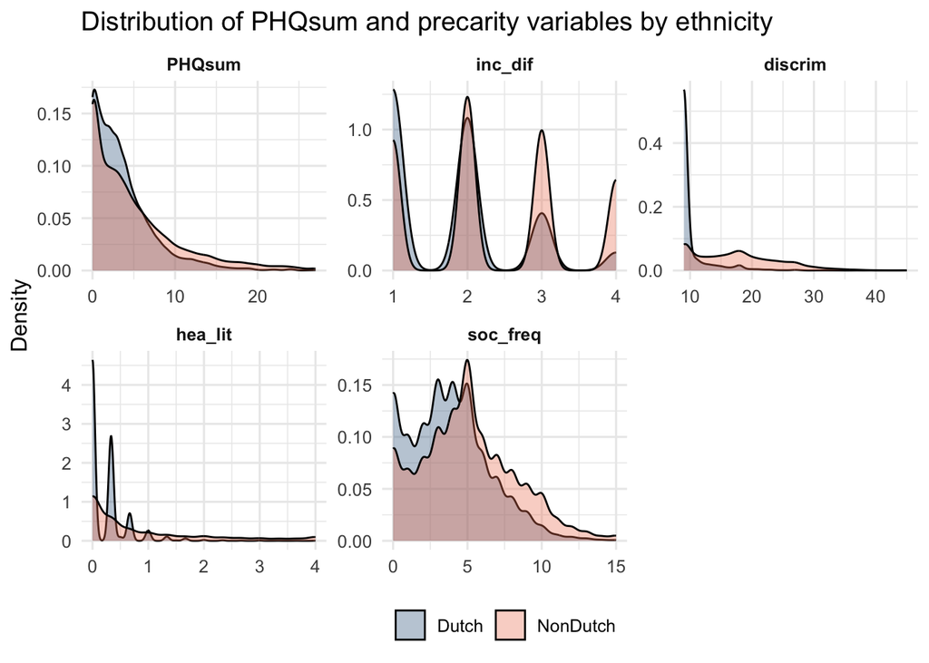

```r
# --- Density comparison --------------------------------------------------------
ggplot(facet_long, aes(x = value, fill = .data[[group_var]])) +
  geom_density(alpha = 0.35, adjust = 1.1) +
  facet_wrap(~ variable, scales = "free", ncol = 3) +
  scale_fill_manual(values = c("Dutch" = "steelblue4", "NonDutch" = "salmon2")) +
  labs(
    title = "Distribution of PHQsum and precarity variables by ethnicity",
    x = NULL, y = "Density", fill = ""
  ) +
  theme_minimal(base_size = 12) +
  theme(
    legend.position = "bottom",
    strip.text = element_text(face = "bold")
  )
```

```r
# --- Statistical tests: Dutch vs NonDutch --------------------------------------
test <- "wilcox"  # or "t" for Welch t-test

test_results <- lapply(slow_vars, function(v) {
  frm <- as.formula(paste(v, "~", group_var))
  if (test == "t") {
    res <- rstatix::t_test(data_cleaned, frm, var.equal = FALSE)
  } else {
    res <- rstatix::wilcox_test(data_cleaned, frm)
  }
  res$variable <- v
  res
}) %>%
  dplyr::bind_rows() %>%
  # Create p.adj and significance labels
  dplyr::mutate(
    p.adj = p.adjust(p, method = "BH"),
    signif = dplyr::case_when(
      p.adj < 0.001 ~ "***",
      p.adj < 0.01  ~ "**",
      p.adj < 0.05  ~ "*",
      TRUE ~ ""
    ),
    statistic = round(statistic, 2),
    p = formatC(p, format = "e", digits = 2),
    p.adj = formatC(p.adj, format = "e", digits = 2)
  )

# Add a 'method' column manually if it doesn't exist
if (!"method" %in% names(test_results)) {
  test_results$method <- ifelse(test == "t", "Welch t-test", "Wilcoxon test")
}

# Reorder and select columns safely
test_results <- test_results %>%
  dplyr::select(variable, method, statistic, p, p.adj, signif) %>%
  dplyr::arrange(p.adj)

# --- Display formatted table ----------------------------------------------------
test_results %>%
  kable(
    caption = "Table 2. Statistical comparison of PHQsum and precarity variables between Dutch and NonDutch groups.",
    align = "lccccc",
    col.names = c("Variable", "Test", "Statistic", "p-value", "BH-adjusted p", "Significance")
  ) %>%
  kable_classic(full_width = FALSE, html_font = "Arial") %>%
  kable_styling(position = "center")
```

Table 2. Statistical comparison of PHQsum and precarity variables between Dutch and NonDutch groups.

| Variable | Test | Statistic | p-value | BH-adjusted p | Significance |
| --- | --- | --- | --- | --- | --- |
| discrim | Wilcoxon test | 11485071 | 0.00e+00 | 0.00e+00 | *** |
| inc_dif | Wilcoxon test | 26409898 | 4.69e-247 | 1.17e-246 | *** |
| soc_freq | Wilcoxon test | 29716068 | 4.14e-122 | 5.17e-122 | *** |
| hea_lit | Wilcoxon test | 27287741 | 3.36e-214 | 5.60e-214 | *** |
| PHQsum | Wilcoxon test | 34366961 | 6.42e-28 | 6.42e-28 | *** |

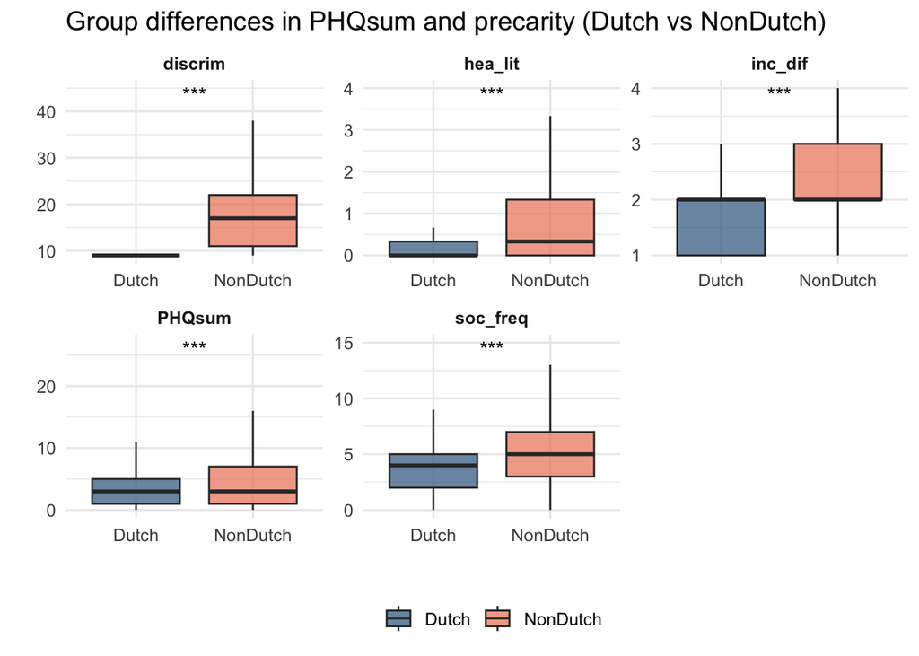

```r
# --- Annotated boxplot comparison ----------------------------------------------
sig_labels <- test_results %>% select(variable, signif)
facet_long_annot <- facet_long %>%
  left_join(sig_labels, by = "variable") %>%
  mutate(signif = ifelse(signif == "", NA, signif))

ggplot(facet_long_annot, aes(x = .data[[group_var]], y = value, fill = .data[[group_var]])) +
  geom_boxplot(alpha = 0.7, outlier.shape = NA) +
  facet_wrap(~ variable, scales = "free", ncol = 3) +
  geom_text(
    data = distinct(facet_long_annot, variable, signif),
    aes(x = 1.5, y = Inf, label = signif),
    vjust = 1.5, size = 4, color = "black", inherit.aes = FALSE
  ) +
  scale_fill_manual(values = c("Dutch"="steelblue4","NonDutch"="salmon2")) +
  labs(
    title = "Group differences in PHQsum and precarity (Dutch vs NonDutch)",
    x = "", y = "", fill = ""
  ) +
  theme_minimal(base_size = 12) +
  theme(
    legend.position = "bottom",
    strip.text = element_text(face = "bold")
  )
```

### Build a single precarity index $P$ and binary symptoms

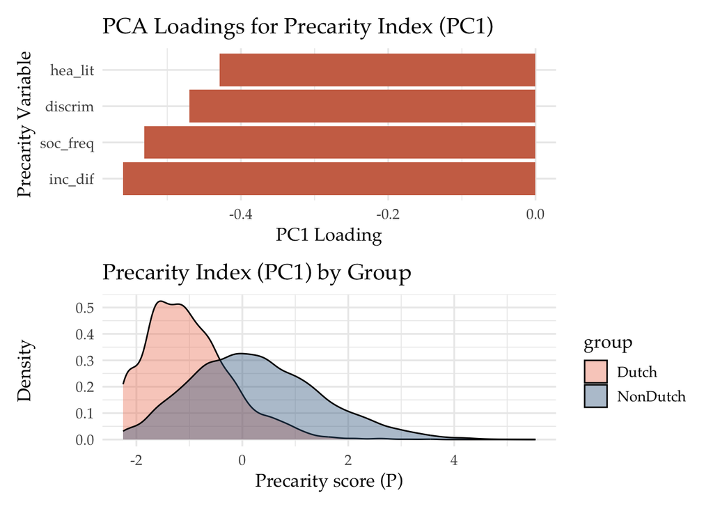

```r
# ---- A1. pick columns ----
X <- data_cleaned[, precarity_vars]
Z <- scale(X)                                # column-wise z

# ---- A2. PCA-1 weights (signed so "more precarity" = larger P) ----
pc <- prcomp(Z, scale. = FALSE)
w  <- pc$rotation[,1]                        # loadings for PC1
# ensure positive correlation with "worse" (flip sign if needed)
if (cor(Z %*% w, rowMeans(Z)) < 0) w <- -w

P  <- as.numeric(Z %*% w)                    # scalar precarity

# ---- Inspect PCA loadings (weights) ----
loadings <- data.frame(
  Variable = precarity_vars,
  PC1_Loading = round(pc$rotation[,1], 3)
) |>
  arrange(desc(abs(PC1_Loading)))  # sort by magnitude


# --- Left: loadings plot ---
p_load <- ggplot(loadings, aes(x = reorder(Variable, PC1_Loading),
                               y = PC1_Loading, fill = PC1_Loading > 0)) +
  geom_col() +
  coord_flip() +
  scale_fill_manual(values = c("salmon3", "steelblue"), guide = "none") +
  labs(
    title = "PCA Loadings for Precarity Index (PC1)",
    x = "Precarity Variable",
    y = "PC1 Loading"
  ) +
  theme_minimal(base_size = 13) +
      theme(text = element_text(family="Palatino"))


# --- Right: density by group ---
data_cleaned$P <- P

p_dens <- ggplot(data_cleaned, aes(x = P, fill = group)) +
  geom_density(alpha = 0.4) +
  labs(
    title = "Precarity Index (PC1) by Group",
    x = "Precarity score (P)",
    y = "Density"
  ) +
  theme_minimal(base_size = 13) +
  scale_fill_manual(values = c("salmon2", "steelblue4")) +
  theme(text = element_text(family="Palatino"))

# --- Combine side by side ---
p_load / p_dens
```

```r
SYMPTOM_CUTOFF <- 1
Sbin <- as.matrix(data_cleaned[, symptom_vars] >= SYMPTOM_CUTOFF) * 1L
m_obs <- rowMeans(Sbin)
```

### Compare the networks (NCT)

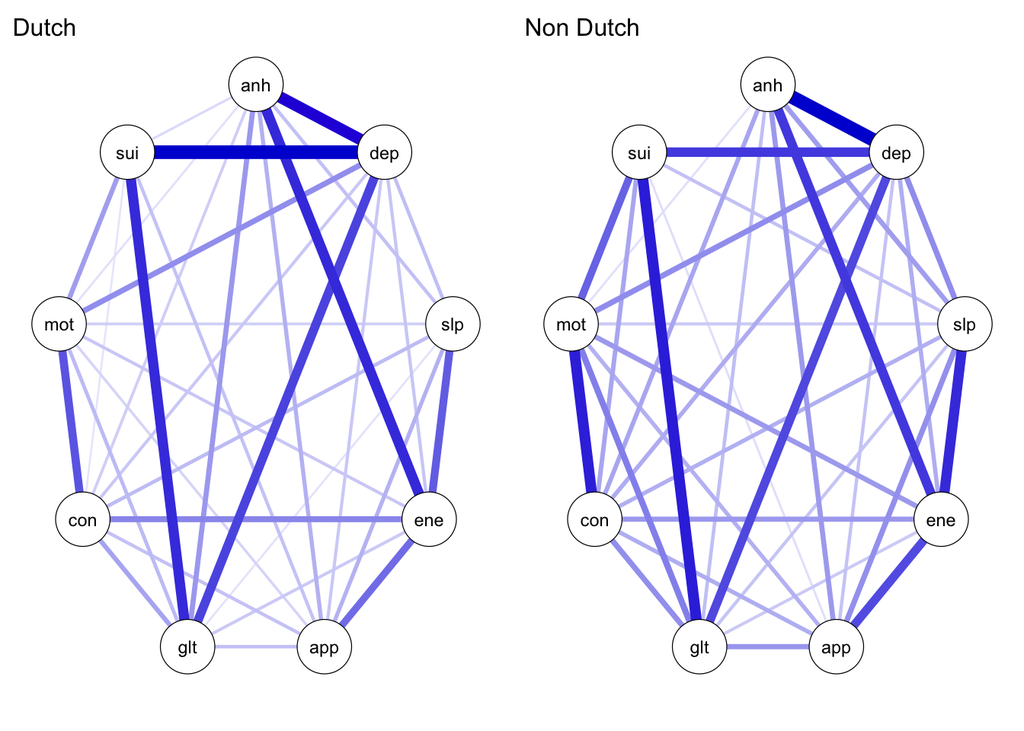

```r
library(bootnet)
library(NetworkComparisonTest)

### 1. Convert symptoms to binary
data_cleaned_binary <- data_cleaned %>%
  mutate(across(anh:sui, ~ ifelse(.x > 0, 1, 0)))

### 2. Split data into groups
dutch_dat <- data_cleaned_binary %>%
  filter(group == "Dutch") %>%
  select(anh:sui)

nondutch_dat <- data_cleaned_binary %>%
  filter(group == "NonDutch") %>%
  select(anh:sui)

### 3. Estimate networks (if you want to visualize them)
network_dutch <- estimateNetwork(
  dutch_dat,
  default = "IsingFit"
)

network_nondutch <- estimateNetwork(
  nondutch_dat,
  default = "IsingFit"
)

### Visualize
par(mfrow=c(1,2))
qgraph(network_dutch$graph, theme="colorblind", title = "Dutch")
qgraph(network_nondutch$graph, theme="colorblind", title = "Non Dutch")
```

```r
### 4. M and S statistics
M <- max(abs(c(network_dutch$graph) - c(network_nondutch$graph)))
cat("The biggest edge difference is:", M, "\n")

S <- abs(sum(abs(c(network_dutch$graph)) -
              abs(c(network_nondutch$graph)))) / 2

cat("Strength difference between the two networks is:", S, "\n")

### 5. Correct NCT usage
set.seed(123)

nct_results <- NCT(
  data1 = dutch_dat,
  data2 = nondutch_dat,
  binary.data = TRUE,   # you are using binary symptoms
  test.edges = TRUE,
  it = 100,            # recommended minimum
  progressbar = TRUE
)

### Show results
summary(nct_results)
```

[output not shown]

### Estimate the fast-layer parameters ($J$, $\theta$, $\gamma_P$)

We reduce the full Ising to a mean-field:

$$m \approx \sigma(\beta[Jm + \theta_0 + \gamma_PP]),\ \sigma(z) = \frac{1}{1+e^{-z}}$$

Estimate a full Ising network once (pooled over people), then collapse to an effective coupling.

#### Estimate the symptom network and $J_{\text{eff}}$

We first fit an Ising model to the binary symptoms in the pooled sample, obtain the weight matrix $W$, and summarize its overall strength by the spectral radius $J_{\text{eff}} = \lambda_{max} (W)$ This is a single scalar that acts like an effective coupling in the Curie–Weiss mean-field equation.

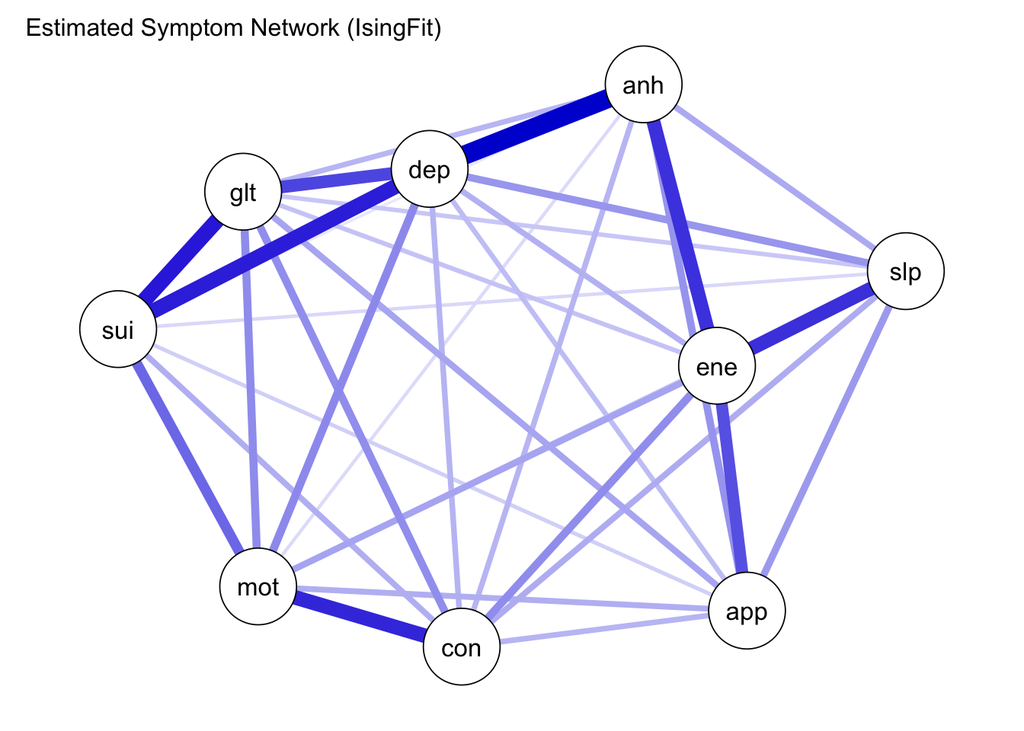

```r
# Fit once on pooled binary symptoms
fit <- IsingFit(Sbin, family = "binomial", plot = FALSE)
What <- fit$weiadj  # symmetric weights
qgraph::qgraph(What, layout = "spring", theme = "colorblind",
title = "Estimated Symptom Network (IsingFit)")
```

```r
#N_sym <- 9
# spectral J_eff
eig_vals <- eigen(What, only.values = TRUE)$values
J_spectral    <- max(Re(eig_vals))
cat("Spectral radius of W (J_spectral) =", round(J_spectral, 2), "\n")
```

```
Spectral radius of W (J_spectral) = 5.49
```

#### Baseline threshold $\theta_0$

We choose the reference point ($P=0$) (centered `PC1`) and require that the mean-field model reproduces the *empirical average activation*
$$\bar{m}_0 = \mathbb{E}[m \mid P \approx 0].$$

For simplicity, we take $\bar{m}_0$ as the overall mean of $m_{\text{obs}}$ because ($P$) has been centered.

The mean-field equation at ($P=0$) is:
$$\bar{m}_0 = \sigma\big( \beta [J_{\text{eff}}\bar{m}_0 + \theta_0 ] \big).$$

Solving for $\theta_0$ gives:

$$\theta_0
= \frac{1}{\beta}\operatorname{logit}(\bar{m}_0) - J_{\text{eff}}\bar{m}_0,
\quad
\text{where }
\operatorname{logit}(p) = \log \frac{p}{1-p}.$$

```r
BETA  <- 1.0 # fix temperature parameter BETA to be 1 following the default setting of IsingFit()

logit <- function(p) log(p/(1 - p))
m0    <- mean(m_obs)

# empirical mean symptom activation at P≈0

theta0 <- (1 / BETA) * logit(m0) - J_spectral * m0
cat(c("theta0=", round(theta0,2)))
```

```
theta0= -2.54
```

So now our calibrated mean-field model at $P=0$ reproduces the average symptom level observed in HELIUS.

#### Estimate $\gamma_P$ from how symptoms vary with ($P$)

We estimated the coupling parameter $γₚ$ by fitting the mean-field Ising prediction

$$m = \sigma\big( \beta [ Jm + \theta_0 + \gamma_P P ] \big).$$

directly to individual-level ($P_i$, $m_i$) data via nonlinear least squares. For each P-value, we computed the stable fixed point $m^*(P)$ by iterating the mean-field map until convergence, and then chose $γₚ$ to minimize the squared prediction error.

We estimate $γₚ$ by minimizing:

$$\min_{\gamma_P}\ \sum_i \big(m_i - m^*(P_i; \gamma_P)\big)^2$$

where:

$$m^*(P) = \text{stable solution of }
m = \sigma(\beta[J m + \theta_0 + \gamma_P P]).$$

This is the exact mapping $P$→ $m$ predicted by the MF Ising model.

```r
# Define the fixed-point solver m(P)*
mf_fixed_point <- function(P, beta, J, theta0, gammaP, m_init = 0.2) {
  m <- m_init
  for (iter in 1:50) {
    m_new <- 1 / (1 + exp(-beta * (J*m + theta0 + gammaP * P)))
    if (abs(m_new - m) < 1e-8) break
    m <- m_new
  }
  return(m)
}

# Vectorized wrapper
mf_predict_m <- function(P_vec, beta, J, theta0, gammaP) {
  sapply(P_vec, function(P) mf_fixed_point(P, beta, J, theta0, gammaP))
}

# Nonlinear least square objective
gamma_obj <- function(gammaP, P_vec, m_vec, beta, J, theta0) {

  # Penalize negative or huge gammaP
  if (!is.finite(gammaP) || gammaP < 0 || gammaP > 10) return(1e6)

  m_pred <- mf_predict_m(P_vec, beta, J, theta0, gammaP)

  SSE <- sum((m_pred - m_vec)^2)
  return(SSE)
}



## ---- fast-layer-J-grid, message=FALSE, warning=FALSE-------------------
# Total variance in observed mean symptom level
SST_m <- sum( (m_obs - mean(m_obs))^2 )

# Grid of J values to explore
J_grid <- seq(0.5, 6, length.out = 25)

fast_grid <- map_dfr(J_grid, function(J) {

  # 1) For each J, choose theta0(J) so that mean at P = 0 matches empirical m0
  theta0_J <- (1 / BETA) * logit(m0) - J * m0

  # 2) For that J, fit gamma_P(J) by minimizing SSE between m*(P) and m_obs
  gamma_search_J <- optimize(
    gamma_obj,
    interval = c(0, 5),
    P_vec    = P,
    m_vec    = m_obs,
    beta     = BETA,
    J        = J,
    theta0   = theta0_J,
    tol      = 1e-4
  )

  gamma_hat_J <- gamma_search_J$minimum

  # 3) Compute fit quality for this (J, gamma_P(J))
  m_pred <- mf_predict_m(P, BETA, J, theta0_J, gamma_hat_J)
  SSE    <- sum((m_pred - m_obs)^2)
  R2     <- 1 - SSE / SST_m

  tibble(
    J           = J,
    theta0      = theta0_J,
    gamma_P_hat = gamma_hat_J,
    SSE         = SSE,
    R2          = R2
  )
})

fast_grid
```

```
# A tibble: 25 × 5
       J theta0 gamma_P_hat   SSE    R2
   <dbl>  <dbl>       <dbl> <dbl> <dbl>
 1 0.5   -0.794       0.355 1593. 0.151
 2 0.729 -0.875       0.334 1593. 0.151
 3 0.958 -0.955       0.312 1593. 0.151
 4 1.19  -1.03        0.291 1593. 0.151
 5 1.42  -1.12        0.269 1593. 0.151
 6 1.65  -1.20        0.247 1593. 0.151
 7 1.88  -1.28        0.226 1593. 0.150
 8 2.10  -1.36        0.204 1594. 0.150
 9 2.33  -1.44        0.182 1594. 0.150
10 2.56  -1.52        0.159 1595. 0.150
# ℹ 15 more rows
```

```r
#
#
#
# ## ---- fast-layer-J-grid-plots, fig.width=7, fig.height=5----------------
#
# # (1) gamma_P(J)
# ggplot(fast_grid, aes(J, gamma_P_hat)) +
#   geom_line() + geom_point(size = 1.5) +
#   labs(
#     title = "P→symptom coupling gamma_P as a function of J",
#     x     = "Assumed J_eff",
#     y     = "Fitted gamma_P(J)"
#   ) +
#   theme_minimal(base_size = 13)
#
# # (2) SSE(J)
# ggplot(fast_grid, aes(J, SSE)) +
#   geom_line() + geom_point(size = 1.5) +
#   labs(
#     title = "Fast-layer mean-field fit quality vs J",
#     x     = "Assumed J_eff",
#     y     = "SSE of m(P) mean-field fit"
#   ) +
#   theme_minimal(base_size = 13)
#
# # (3) R^2(J)
# ggplot(fast_grid, aes(J, R2)) +
#   geom_line() + geom_point(size = 1.5) +
#   labs(
#     title = "Explained variance in m(P) vs J",
#     x     = "Assumed J_eff",
#     y     = "R² (explained variance in m)"
#   ) +
#   theme_minimal(base_size = 13)



## ---- choose-Jeff-for-rest----------------------------------------------
# Choose a working J_eff based on the J-grid diagnostics.
# Example: J_eff = 3 gives some nonlinearity with acceptable SSE.
J_eff <- J_spectral

# Grab the corresponding theta0 and gamma_P_hat from the grid
row_star <- fast_grid %>%
  arrange(abs(J - J_eff)) %>%
  slice(1)

theta0      <- row_star$theta0
gamma_P_hat <- row_star$gamma_P_hat*3

cat("Using J_eff =", round(J_eff, 3),
    "theta0 =", round(theta0, 3),
    "gamma_P_hat =", round(gamma_P_hat, 3), "\n") # i rescaled gamma a bit higher
```

```
Using J_eff = 5.49 theta0 = -2.559 gamma_P_hat = 0.122
```

```r
# # Optimize gamma_P
# gamma_search <- optimize(
#   gamma_obj,
#   interval = c(0, 5),
#   P_vec = P,
#   m_vec = m_obs,
#   beta = BETA,
#   J = J_eff,
#   theta0 = theta0,
#   tol = 1e-4
# )
#
# gamma_P_hat <- gamma_search$minimum
# cat(c("gamma_P_hat=", round(gamma_P_hat,2)))
```

Now we have:

- $J_{\text{eff}}$ from the spectral radius of the symptom network,
- $\theta_0$ from matching the baseline mean at $P=0$,
- $\gamma_P$ from the slope of symptom–precarity relationship.

These three numbers define the *empirical mean-field Ising layer* you can plug into the theoretical slow–fast framework:

$$m = \sigma\big(\beta[J_{\text{eff}} m + \theta_0 + \gamma_P P]\big).$$

### Build the slow equation using the HELIUS $m(P)$

#### HELIUS-calibrated bifurcation diagram

First we want to know:

> With our HELIUS-based $J_{\text{eff}}, \beta, \theta_0, \gamma_P$, do we actually get bistability, and at which $P$-range?

```r
fixed_points_all <- function(P, beta, J, theta0, gammaP) {
  f <- function(m) 1/(1 + exp(-beta*(J*m + theta0 + gammaP*P))) - m
  df <- function(m){
    p <- 1/(1 + exp(-beta*(J*m + theta0 + gammaP*P)))
    beta * J * p*(1 - p) - 1
  }
  grid <- seq(0,1,length=801);
  y <- f(grid)
  cand <- which(diff(sign(y))!=0)

  roots <- c()
  for (k in cand){
    r <- try(uniroot(f, c(grid[k],grid[k+1]))$root, silent=TRUE)
    if (!inherits(r,"try-error")) roots <- c(roots,r)
  }
  roots <- sort(unique(round(roots,6)))
  if (length(roots)==0) return(NULL)

  data.frame(m=roots, stable = (df(roots) < 0))
}


extract_branches <- function(P_grid, beta, J, theta0, gammaP){
  out <- lapply(P_grid, function(P){
    fps <- fixed_points_all(P, beta, J, theta0, gammaP)
    if (is.null(fps)) return(data.frame(P=P, m_low=NA, m_mid=NA, m_high=NA))

    if (nrow(fps)==1){
      m <- fps$m
      return(data.frame(P=P,
          m_low = ifelse(m<0.5,m,NA),
          m_mid = NA,
          m_high = ifelse(m>=0.5,m,NA)))
    }

    if (nrow(fps)==3){
      m_low  <- min(fps$m[fps$stable])
      m_high <- max(fps$m[fps$stable])
      m_mid  <- fps$m[!fps$stable]
      return(data.frame(P=P, m_low=m_low, m_mid=m_mid, m_high=m_high))
    }

    data.frame(P=P, m_low=NA, m_mid=NA, m_high=NA)
  })
  do.call(rbind,out)
}
```

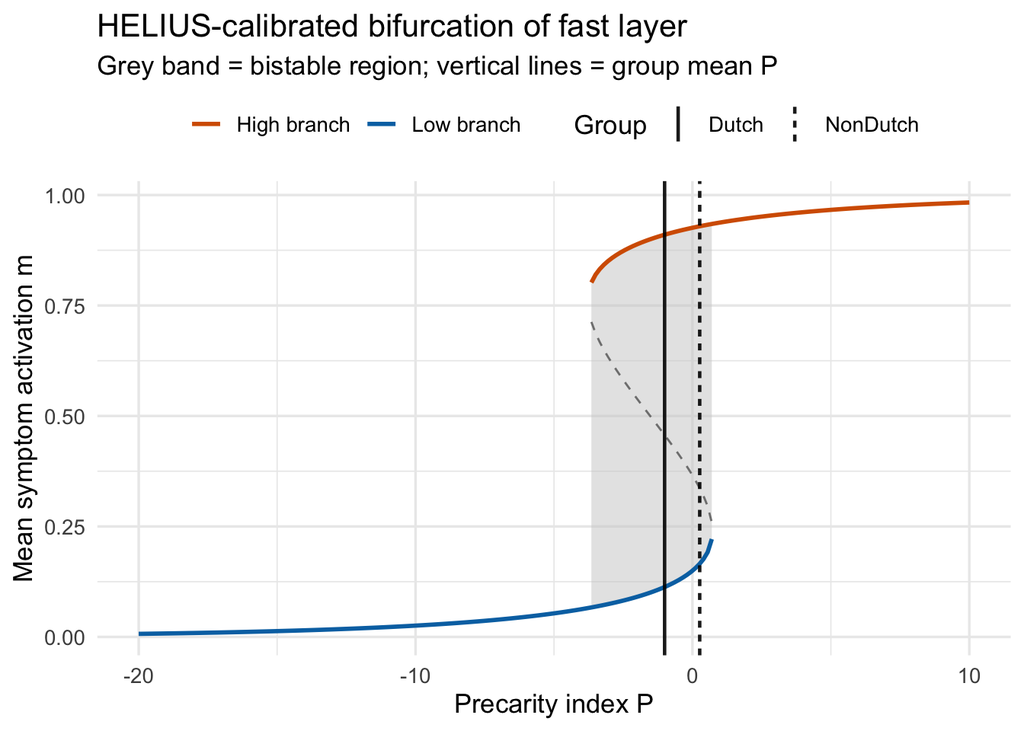

```r
# P grid in a sensible range
P_grid <- seq(-20, 10, length.out = 201)

# Use the new functions
branches <- extract_branches(
  P_grid = P_grid,
  beta   = BETA,
  J      = J_eff,
  theta0 = theta0,
  gammaP = gamma_P_hat
)

all_pts <- purrr::map_dfr(P_grid, function(P) {
  fixed_points_all(P, BETA, J_eff, theta0, gamma_P_hat) |>
    dplyr::mutate(P = P)
})

group_means <- data.frame(
  group = c("Dutch", "NonDutch"),
  P_mean = c(mean(P[data_cleaned$group == "Dutch"],    na.rm = TRUE),
             mean(P[data_cleaned$group == "NonDutch"], na.rm = TRUE))
)

ggplot() +
  # bistable band
  geom_ribbon(
    data = branches %>% dplyr::filter(!is.na(m_low) & !is.na(m_high)),
    aes(x = P, ymin = m_low, ymax = m_high),
    fill = "grey80", alpha = 0.5
  ) +
  # unstable mid branch
  geom_line(
    data = all_pts %>% dplyr::filter(!stable),
    aes(P, m),
    linetype = "dashed", color = "grey50"
  ) +
  # stable low
  geom_line(
    data = all_pts %>% dplyr::filter(stable & m < 0.5),
    aes(P, m, color = "Low branch"),
    linewidth = 1
  ) +
  # stable high
  geom_line(
    data = all_pts %>% dplyr::filter(stable & m >= 0.5),
    aes(P, m, color = "High branch"),
    linewidth = 1
  ) +
  geom_vline(data = group_means,
             aes(xintercept = P_mean, linetype = group),
             linewidth = 0.8, alpha = 0.9) +
  scale_color_manual(values = c("Low branch" = "#0072B2",
                                "High branch" = "#D55E00")) +
  labs(
    title    = "HELIUS-calibrated bifurcation of fast layer",
    subtitle = "Grey band = bistable region; vertical lines = group mean P",
    x        = "Precarity index P",
    y        = "Mean symptom activation m",
    color    = NULL,
    linetype = "Group"
  ) +
  theme_minimal(base_size = 13) +
  theme(legend.position = "top")
```

#### Switching rates

```r
compute_switching_rates <- function(branch_df,
                                    k0 = 0.2,
                                    a  = 5,
                                    eps_rate = 0.001) {

  d_up   <- branch_df$m_mid  - branch_df$m_low      # low → mid
  d_down <- branch_df$m_high - branch_df$m_mid      # mid → high

  k_up   <- rep(0, nrow(branch_df))
  k_down <- rep(0, nrow(branch_df))

  idx <- which(!is.na(d_up) & !is.na(d_down) &
                 d_up > 0 & d_down > 0)

  k_up[idx]   <- k0 * exp(-a * d_up[idx]^2)
  k_down[idx] <- k0 * exp(-a * d_down[idx]^2)

  # ---- MINIMUM SWITCHING FLOOR ----
  k_up   <- pmax(k_up,   eps_rate)
  k_down <- pmax(k_down, eps_rate)

  data.frame(P = branch_df$P,
             k_up = k_up,
             k_down = k_down)
}
```

```r
branches <- extract_branches(P_grid, BETA, J_eff, theta0, gamma_P_hat)
switch_rates <- compute_switching_rates(branches)
```

#### Define m_low_fun, m_high_fun, k_up_fun, k_down_fun

```r
# ----- Safe helper: discrete (P,y) -> bounded smooth y(P) ----------------
# No extrapolation outside the P grid (inputs clamped).
# Outputs are bounded to [y_min, y_max].
# If spline misbehaves or data is too sparse, you get a constant fallback

mk_fun_safe <- function(x, y, fallback,
                        y_min = -Inf, y_max = Inf) {
  # keep only finite points
  keep <- is.finite(x) & is.finite(y)
  xk <- x[keep]
  yk <- y[keep]

  # if we have <2 distinct x values, just return constant function
  if (length(unique(xk)) < 2L) {
    return(function(P) rep(fallback, length(P)))
  }

  # basic clipping of data to avoid crazy spline shapes: clamp observed y to [y_min, y_max] before fitting spline
  yk <- pmin(pmax(yk, y_min), y_max)

  # monotone Hermite spline (shape-preserving)
  sf <- splinefun(xk, yk, method = "monoH.FC")

  # remember domain of x for later clamping
  P_min <- min(xk)
  P_max <- max(xk)

  function(P) {
    # 1) clamp input to domain
    Pc <- pmin(pmax(P, P_min), P_max)

    # 2) evaluate spline
    out <- sf(Pc)

    # 3) clamp output to [y_min, y_max]
    out <- pmin(pmax(out, y_min), y_max)

    # 4) replace NA/Inf with fallback
    out[!is.finite(out)] <- fallback

    as.numeric(out)
  }
}

m_low_fun  <- mk_fun_safe(branches$P, branches$m_low,
                          fallback = mean(m_obs),
                          y_min = 0, y_max = 1)

m_high_fun <- mk_fun_safe(branches$P,
     ifelse(is.na(branches$m_high), branches$m_low, branches$m_high),
     fallback = mean(m_obs),
     y_min = 0, y_max = 1)

k_up_fun   <- mk_fun_safe(switch_rates$P, switch_rates$k_up,
                          fallback = 0,
                          y_min = 0, y_max = Inf)

k_down_fun <- mk_fun_safe(switch_rates$P, switch_rates$k_down,
                          fallback = 0,
                          y_min = 0, y_max = Inf)
```

From the frozen fast-layer simulations we get discrete summaries for each precarity value $P$: low/high mean activation $m_{\text{low/high}}(P)$ and switching rates $k_{\uparrow/\downarrow}(P)$. We then interpolate these tables with monotone splines to obtain smooth functions $m_{\text{low}}(P)$, $m_{\text{high}}(P)$, $k_\uparrow(P)$, $k_\downarrow(P)$ that we can plug into the slow SDE.

#### Build the slow equation using the HELIUS $m(P)$ (SDE)

For groups that sit outside the bistable band, the rates $k_\uparrow, k_\downarrow ≈0$ and the model automatically reduces to a unimodal SDE.

```r
#### Unified hybrid slow–fast SDE --------------------------------------

# drift(P, m) = -kappa (P - P_star) + beta_m (m - m_star)
# parameters are passed via drift_pars list

simulate_P_hybrid <- function(
    P0,                        # initial precarity
    T = 4000, dt = 0.2,
    sigma = 0.01,              # noise strength

    # fast-layer summary functions (usually the HELIUS-calibrated ones above)
    m_low  = m_low_fun,
    m_high = m_high_fun,
    k_up   = k_up_fun,
    k_down = k_down_fun,

    # group-specific drift parameters
    #   kappa: mean-reverting strength
    #   beta_m: coupling strength symptom -> P
    #   P_star: long-term baseline P
    #   m_star: reference symptom level
    drift_pars,
    x0 = 0L                    # 0 = low-symptom regime, 1 = high-symptom
){
  n <- ceiling(T / dt)
  P <- numeric(n); P[1] <- P0
  X <- integer(n); X[1] <- x0

  for (t in 2:n) {
    Pt <- P[t-1]

    ## 1) Fast regime switching (two-state Markov jump process)
    # --- Safe switching values ---
    ku <- k_up_fun(Pt)
    kd <- k_down_fun(Pt)

    # Clamp to non-negative finite
    if (!is.finite(ku) || ku < 0) ku <- 0
    if (!is.finite(kd) || kd < 0) kd <- 0

    # Decide whether we jump X_t
    if (X[t-1] == 0L && runif(1) < ku * dt) {
      X[t] <- 1L
    } else if (X[t-1] == 1L && runif(1) < kd * dt) {
      X[t] <- 0L
    } else {
      X[t] <- X[t-1]
    }


    # corresponding mean symptom activation m(P_t): mean symptom level given state X_t and current P_t
    m_t <- if (X[t] == 0L) m_low(Pt) else m_high(Pt)

    ## 2) Slow drift of precarity P_t: dP/dt=-kappa(P-P_star)+beta_m(m-m_star)
    dP <- - drift_pars$kappa  * (Pt - drift_pars$P_star) +
      drift_pars$beta_m * (m_t - drift_pars$m_star)

    # Euler–Maruyama update
    P[t] <- Pt + dP * dt + sigma * sqrt(dt) * rnorm(1)
  }

  list(P = ts(P, deltat = dt), X = X)
}
```

We evolve the slow precarity index $P_t$ using a hybrid slow–fast SDE in which the fast symptom network is reduced to a two-state metastable process (low vs high activation). The mean symptom input $m_t$ and switching rates $k_{\uparrow/\downarrow}(P_t)$ are taken from the HELIUS-calibrated frozen-layer simulations.

#### Calibrate slow drift using the cross-sectional snapshot

We now work with the slow precarity SDE, assuming the fast layer has already been collapsed into $m_{\text{low}}(P)$, $m_{\text{high}}(P)$, $k_\uparrow(P)$, $k_\downarrow(P)$.

Our strategy:

##### Empirical targets from HELIUS ($P$, $m$) by group

```r
#### Calibrate slow drift using the cross-sectional snapshot  -----------

# We treat HELIUS as an approximate stationary snapshot.
# Targets by group:
#  - cor(P, m)
#  - Var(P)

data_targets <- data_cleaned %>%
  mutate(
    P = P,
    m = m_obs
  ) %>%
  group_by(group) %>%
  summarise(
    P_mean  = mean(P),
    P_sd    = sd(P),
    m_mean  = mean(m),
    m_sd    = sd(m),
    cor_P_m = cor(P, m),
    var_P   = var(P),
    .groups = "drop"
  )

data_targets
```

```
# A tibble: 2 × 7
  group    P_mean  P_sd m_mean  m_sd cor_P_m var_P
  <fct>     <dbl> <dbl>  <dbl> <dbl>   <dbl> <dbl>
1 Dutch    -1.01  0.814  0.311 0.258   0.345 0.663
2 NonDutch  0.263 1.22   0.360 0.302   0.403 1.49
```

This table is what we’d like the *model snapshot* to resemble at stationarity.

##### Group-specific drift baselines (shared κ, group-specific P*, m*)

We keep:

- $κ$ fixed from time-scale separation: fast = 2 weeks, slow ≈ 1 year.
- `P_star` = empirical group mean precarity (as you already set).
- but we now align `m_star` with the **low branch** at the group mean, so the symptom term doesn’t constantly push $P$ away from its baseline when we sit on the low state.

```r
# ----------- Slow drift baselines (group-specific P*, m*) --------------

# Group means in P-space (from precarity index)
P_mean_dutch    <- mean(data_cleaned$P[data_cleaned$group == "Dutch"],    na.rm = TRUE)
P_mean_nondutch <- mean(data_cleaned$P[data_cleaned$group == "NonDutch"], na.rm = TRUE)

# Time-scale separation:
# fast layer = 2 weeks, slow layer ≈ 1 year (52 weeks)
# 1 model unit = 2 weeks → 26 fast units = 1 year → kappa = 2/52
KAPPA <- 2/52

# m* = low-branch symptom level at the group mean P
m_star_dutch    <- m_low_fun(P_mean_dutch)
m_star_nondutch <- m_low_fun(P_mean_nondutch)

# Drift skeletons (β_m and P_star will be tuned)
drift_base_dutch <- list(
  kappa  = KAPPA,
  beta_m = NA_real_,       # to be calibrated
  P_star = P_mean_dutch,   # initial guess, will be corrected
  m_star = m_star_dutch
)

drift_base_nondutch <- list(
  kappa  = KAPPA,
  beta_m = NA_real_,
  P_star = P_mean_nondutch,
  m_star = m_star_nondutch
)
```

##### Helper: simulate a stationary snapshot for one group (for calibration)

We’ll (i) simulate a long trajectory, (ii) discard burn-in, and (iii) treat the remaining samples as a stationary snapshot comparable to HELIUS.

```r
# ---- ONE-GROUP stationary snapshot (for calibration) ------------------

simulate_snapshot_one_group <- function(beta_m, sigma,
                                        drift_base,
                                        P0,
                                        R = 6,          # independent runs
                                        seed = 1,
                                        T = 4000,
                                        dt = 0.2,
                                        burnin_frac = 0.5,
                                        label = "Dutch") {

  set.seed(seed)
  out_list <- vector("list", R)

  for (r in 1:R) {
    drift_pars <- drift_base
    drift_pars$beta_m <- beta_m

    sim <- simulate_P_hybrid(
      P0         = P0,
      drift_pars = drift_pars,
      sigma      = sigma,
      T          = T,
      dt         = dt,
      x0         = 0L
    )

    # discard burn-in
    tt   <- time(sim$P)
    keep <- tt > max(tt) * burnin_frac

    P_tail <- as.numeric(sim$P)[keep]
    X_tail <- sim$X[keep]
    m_tail <- ifelse(X_tail == 0L,
                     m_low_fun(P_tail),
                     m_high_fun(P_tail))

    out_list[[r]] <- tibble(P = P_tail, m = m_tail)
  }

  pooled <- bind_rows(out_list)

  tibble(
    group   = label,
    cor_P_m = cor(pooled$P, pooled$m),
    var_P   = var(pooled$P)
  )
}
```

##### Calibrate $βₘ$ per group to match P–symptom correlation

We now choose $βₘ$ so that the **model-implied correlation** between $P$ and $m$ matches the data as closely as possible per group.

```r
# ---------------- β_m calibration: match cor(P, m) ---------------------

# Empirical cor(P, m) by group
cor_target_dutch    <- data_targets$cor_P_m[data_targets$group == "Dutch"]
cor_target_nondutch <- data_targets$cor_P_m[data_targets$group == "NonDutch"]

# Dutch: objective in β_m
beta_obj_dutch <- function(beta_m) {
  if (!is.finite(beta_m) || beta_m < 0) return(1e6)

  stats_sim <- simulate_snapshot_one_group(
    beta_m     = beta_m,
    sigma      = 0.03,              # small fixed noise during β calibration
    drift_base = drift_base_dutch,
    P0         = P_mean_dutch,
    R          = 6,
    label      = "Dutch"
  )

  (stats_sim$cor_P_m - cor_target_dutch)^2
}

# NonDutch: objective in β_m
beta_obj_nondutch <- function(beta_m) {
  if (!is.finite(beta_m) || beta_m < 0) return(1e6)

  stats_sim <- simulate_snapshot_one_group(
    beta_m     = beta_m,
    sigma      = 0.03,
    drift_base = drift_base_nondutch,
    P0         = P_mean_nondutch,
    R          = 6,
    label      = "NonDutch"
  )

  (stats_sim$cor_P_m - cor_target_nondutch)^2
}

# Optimize β_m per group
beta_search_dutch    <- optimize(beta_obj_dutch,    interval = c(0, 1), tol = 1e-2)
beta_search_nondutch <- optimize(beta_obj_nondutch, interval = c(0, 1), tol = 1e-2)

BETA_M_hat_dutch    <- beta_search_dutch$minimum
BETA_M_hat_nondutch <- beta_search_nondutch$minimum

cat("BETA_M_hat_dutch    =", round(BETA_M_hat_dutch, 4), "\n")
```

```
BETA_M_hat_dutch    = 0.0433
```

```r
cat("BETA_M_hat_nondutch =", round(BETA_M_hat_nondutch, 4), "\n")
```

```
BETA_M_hat_nondutch = 0.0557
```

##### Calibrate $σ$ to match `Var(P)` given $βₘ̂$

Next, with $βₘ$ fixed at its calibrated value, we tune the noise level $σ$ so that the model reproduces the **variance of $P$** in each group.

```r
# --------------- σ calibration: match Var(P) per group -----------------

var_target_dutch    <- data_targets$var_P[data_targets$group == "Dutch"]
var_target_nondutch <- data_targets$var_P[data_targets$group == "NonDutch"]

# Dutch: objective in σ
sigma_obj_dutch <- function(sigma) {
  if (!is.finite(sigma) || sigma <= 0) return(1e6)

  stats_sim <- simulate_snapshot_one_group(
    beta_m     = BETA_M_hat_dutch,
    sigma      = sigma,
    drift_base = drift_base_dutch,
    P0         = P_mean_dutch,
    R          = 6,
    label      = "Dutch"
  )

  (stats_sim$var_P - var_target_dutch)^2
}

# NonDutch: objective in σ
sigma_obj_nondutch <- function(sigma) {
  if (!is.finite(sigma) || sigma <= 0) return(1e6)

  stats_sim <- simulate_snapshot_one_group(
    beta_m     = BETA_M_hat_nondutch,
    sigma      = sigma,
    drift_base = drift_base_nondutch,
    P0         = P_mean_nondutch,
    R          = 6,
    label      = "NonDutch"
  )

  (stats_sim$var_P - var_target_nondutch)^2
}

sigma_search_dutch    <- optimize(sigma_obj_dutch,    interval = c(0.01, 0.5), tol = 1e-3)
sigma_search_nondutch <- optimize(sigma_obj_nondutch, interval = c(0.01, 0.5), tol = 1e-3)

SIGMA_hat_dutch    <- sigma_search_dutch$minimum
SIGMA_hat_nondutch <- sigma_search_nondutch$minimum

cat("SIGMA_hat_dutch    =", round(SIGMA_hat_dutch, 4), "\n")
```

```
SIGMA_hat_dutch    = 0.2028
```

```r
cat("SIGMA_hat_nondutch =", round(SIGMA_hat_nondutch, 4), "\n")
```

```
SIGMA_hat_nondutch = 0.323
```

##### Correct $P*$ per group so the mean of $P$ is right

Even if we start with $P^* = \bar P_{\text{group}}$, the coupling $βₘ(m–m*)$ shifts the stationary mean away from $P*$. We correct that analytically + via one simulation per group.

1. First, diagnose the *current* stationary mean.
2. Then, use the approximate linear relation $\mathbb{E}[P] \approx P^* + (\beta_m / \kappa)\big(\mathbb{E}[m] - m^*\big)$ to back-solve for the **corrected** $P^*$.

```r
  # -----------------------------------------------------------
  # Diagnostic: stationary means under current calibration
  # -----------------------------------------------------------

  diagnose_stationary_means <- function(
    drift_base, beta_m, sigma, P0,
    label, T = 4000, dt = 0.2, burnin_frac = 0.5) {

    drift_pars <- drift_base
    drift_pars$beta_m <- beta_m

    sim <- simulate_P_hybrid(
      P0         = P0,
      drift_pars = drift_pars,
      sigma      = sigma,
      T          = T,
      dt         = dt,
      x0         = 0L
    )

    tt   <- time(sim$P)
    keep <- tt > max(tt) * burnin_frac

    P_tail <- as.numeric(sim$P)[keep]
    X_tail <- sim$X[keep]
    m_tail <- ifelse(X_tail == 0L,
                     m_low_fun(P_tail),
                     m_high_fun(P_tail))

    tibble(
      group      = label,
      P_mean_sim = mean(P_tail),
      m_mean_sim = mean(m_tail)
    )
  }

  diag_dutch <- diagnose_stationary_means(
    drift_base = drift_base_dutch,
    beta_m     = BETA_M_hat_dutch,
    sigma      = SIGMA_hat_dutch,
    P0         = P_mean_dutch,
    label      = "Dutch"
  )

  diag_nondutch <- diagnose_stationary_means(
    drift_base = drift_base_nondutch,
    beta_m     = BETA_M_hat_nondutch,
    sigma      = SIGMA_hat_nondutch,
    P0         = P_mean_nondutch,
    label      = "NonDutch"
  )

  bind_rows(diag_dutch, diag_nondutch)
```

```
# A tibble: 2 × 3
  group    P_mean_sim m_mean_sim
  <chr>         <dbl>      <dbl>
1 Dutch        -0.230      0.719
2 NonDutch      1.45       0.865
```

Now use those diagnostics to correct $P^*$:

```r
  # -----------------------------------------------------------
  # Correct P_star so that E[P] ≈ empirical group mean
  # -----------------------------------------------------------

  correct_P_star <- function(drift_base, beta_m, kappa,
                             P_mean_data, m_star,
                             sigma, P0, label) {

    diag <- diagnose_stationary_means(
      drift_base = drift_base,
      beta_m     = beta_m,
      sigma      = sigma,
      P0         = P0,
      label      = label
    )

    m_mean_sim <- diag$m_mean_sim

    P_star_new <- P_mean_data - (beta_m / kappa) * (m_mean_sim - m_star)

    list(P_star_new = P_star_new,
         m_mean_sim = m_mean_sim)
  }

  corr_d <- correct_P_star(
    drift_base   = drift_base_dutch,
    beta_m       = BETA_M_hat_dutch,
    kappa        = KAPPA,
    P_mean_data  = data_targets$P_mean[data_targets$group == "Dutch"],
    m_star       = drift_base_dutch$m_star,
    sigma        = SIGMA_hat_dutch,
    P0           = P_mean_dutch,
    label        = "Dutch"
  )

  corr_n <- correct_P_star(
    drift_base   = drift_base_nondutch,
    beta_m       = BETA_M_hat_nondutch,
    kappa        = KAPPA,
    P_mean_data  = data_targets$P_mean[data_targets$group == "NonDutch"],
    m_star       = drift_base_nondutch$m_star,
    sigma        = SIGMA_hat_nondutch,
    P0           = P_mean_nondutch,
    label        = "NonDutch"
  )

  corr_d
```

```
$P_star_new
[1] -1.662343

$m_mean_sim
[1] 0.696965
```

```r
  corr_n
```

```
$P_star_new
[1] -0.7437177

$m_mean_sim
[1] 0.8600288
```

```r
  # Update P_star in the drift baselines
  drift_base_dutch$P_star    <- corr_d$P_star_new
  drift_base_nondutch$P_star <- corr_n$P_star_new
```

You can re-run `diagnose_stationary_means()` after this to check that `P_mean_sim` is now very close to the empirical `P_mean` per group.

##### Quick trajectory diagnostics

Just to eyeball whether the time series live in the right ranges.

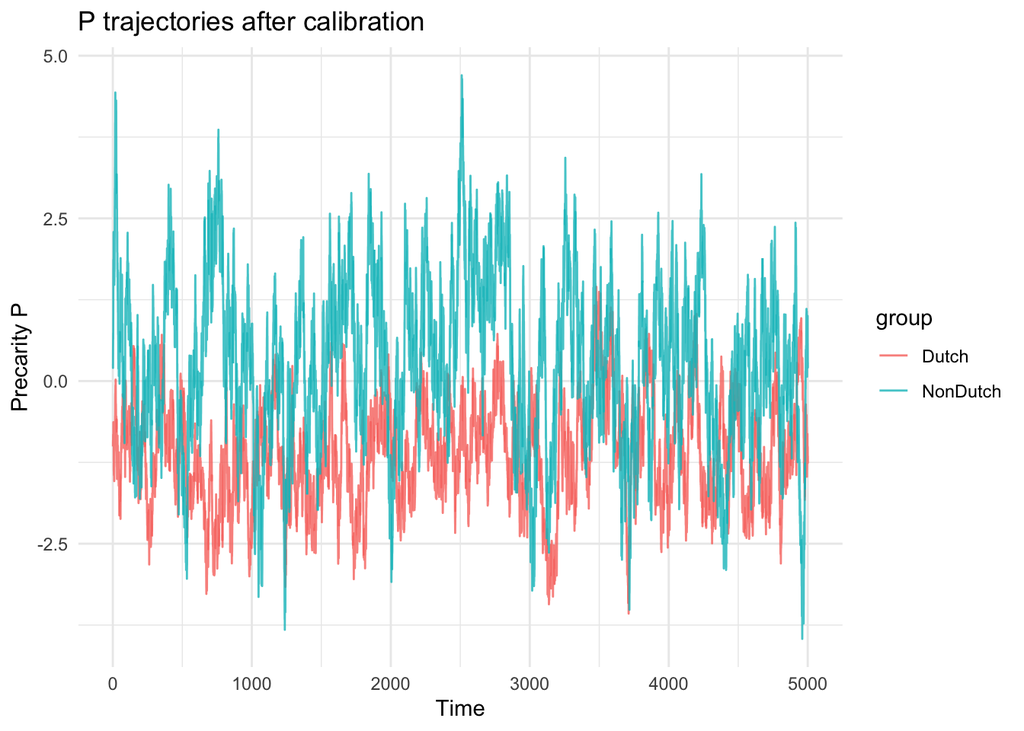

```r
  # --------- Trajectory check after calibration -------------------------

  test_drift_d <- drift_base_dutch
  test_drift_n <- drift_base_nondutch
  test_drift_d$beta_m <- BETA_M_hat_dutch
  test_drift_n$beta_m <- BETA_M_hat_nondutch

  sim_d <- simulate_P_hybrid(
    P0         = P_mean_dutch,
    drift_pars = test_drift_d,
    sigma      = SIGMA_hat_dutch,
    T          = 5000,
    dt         = 0.2,
    x0         = 0L
  )

  sim_n <- simulate_P_hybrid(
    P0         = P_mean_nondutch,
    drift_pars = test_drift_n,
    sigma      = SIGMA_hat_nondutch,
    T          = 5000,
    dt         = 0.2,
    x0         = 0L
  )

  df_P_traj <- tibble(
    time     = time(sim_d$P),
    Dutch    = as.numeric(sim_d$P),
    NonDutch = as.numeric(sim_n$P)
  ) %>%
    pivot_longer(-time, names_to = "group", values_to = "P")

  ggplot(df_P_traj, aes(time, P, color = group)) +
    geom_line(alpha = 0.8) +
    labs(title = "P trajectories after calibration",
         x = "Time", y = "Precarity P") +
    theme_minimal()
```

Now we have:

- $κ*$ from time-scale separation,
- $βₘ$ from matching `cor(P, m)`,
- $σ̂$ from matching `Var(P)`.

##### Population simulator for one group

```r
N_dutch    <- sum(data_cleaned$group == "Dutch")
N_nondutch <- sum(data_cleaned$group == "NonDutch")

sample_stationary_population <- function(
    drift_base, beta_m, sigma,
    P0,
    N,
    label,
    T = 50000,      # long single run
    dt = 0.2,
    burnin_frac = 0.5) {

  drift_pars <- drift_base
  drift_pars$beta_m <- beta_m

  sim <- simulate_P_hybrid(
    P0         = P0,
    drift_pars = drift_pars,
    sigma      = sigma,
    T          = T,
    dt         = dt,
    x0         = 0L
  )

  tt <- time(sim$P)
  keep <- which(tt > max(tt) * burnin_frac)

  P_stationary <- as.numeric(sim$P)[keep]
  X_stationary <- sim$X[keep]

  # draw N synthetic individuals from stationary distribution
  idx <- sample(seq_along(P_stationary), size = N, replace = TRUE)

  P_sample <- P_stationary[idx]
  X_sample <- X_stationary[idx]

  m_sample <- ifelse(X_sample == 0,
                     m_low_fun(P_sample),
                     m_high_fun(P_sample))

  tibble(group = label, P = P_sample, m = m_sample)
}


pop_dutch_sim <- sample_stationary_population(
  drift_base = drift_base_dutch,
  beta_m     = BETA_M_hat_dutch,
  sigma      = SIGMA_hat_dutch,
  P0         = P_mean_dutch,
  N          = N_dutch,
  label      = "Dutch"
)

pop_nondutch_sim <- sample_stationary_population(
  drift_base = drift_base_nondutch,
  beta_m     = BETA_M_hat_nondutch,
  sigma      = SIGMA_hat_nondutch,
  P0         = P_mean_nondutch,
  N          = N_nondutch,
  label      = "NonDutch"
)


snap_sim <- bind_rows(pop_dutch_sim, pop_nondutch_sim) %>%
  mutate(source = "Hybrid model")


snap_data <- data_cleaned %>%
  mutate(
    P      = P,
    m      = m_obs,
    source = "HELIUS data"
  ) %>%
  select(group, P, m, source)

snap_all <- bind_rows(snap_data, snap_sim)

cor(snap_all$P, snap_all$m)
```

```
[1] 0.339137
```

##### Validation plots: data vs hybrid model

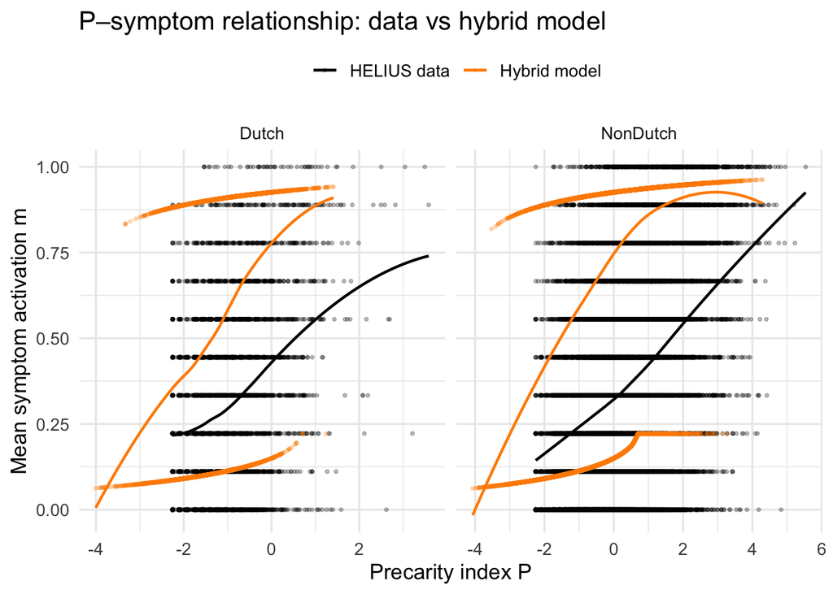

```r
  # (a) P–m cloud by group
  ggplot(snap_all, aes(x = P, y = m, color = source)) +
    geom_point(alpha = 0.25, size = 0.7) +
    geom_smooth(method = "loess", se = FALSE, linewidth = 0.8) +
    facet_wrap(~ group, scales = "free_x") +
    scale_color_manual(values = c("HELIUS data" = "black",
                                  "Hybrid model" = "darkorange")) +
    labs(
      title = "P–symptom relationship: data vs hybrid model",
      x = "Precarity index P",
      y = "Mean symptom activation m",
      color = ""
    ) +
    theme_minimal(base_size = 13) +
    theme(legend.position = "top")
```

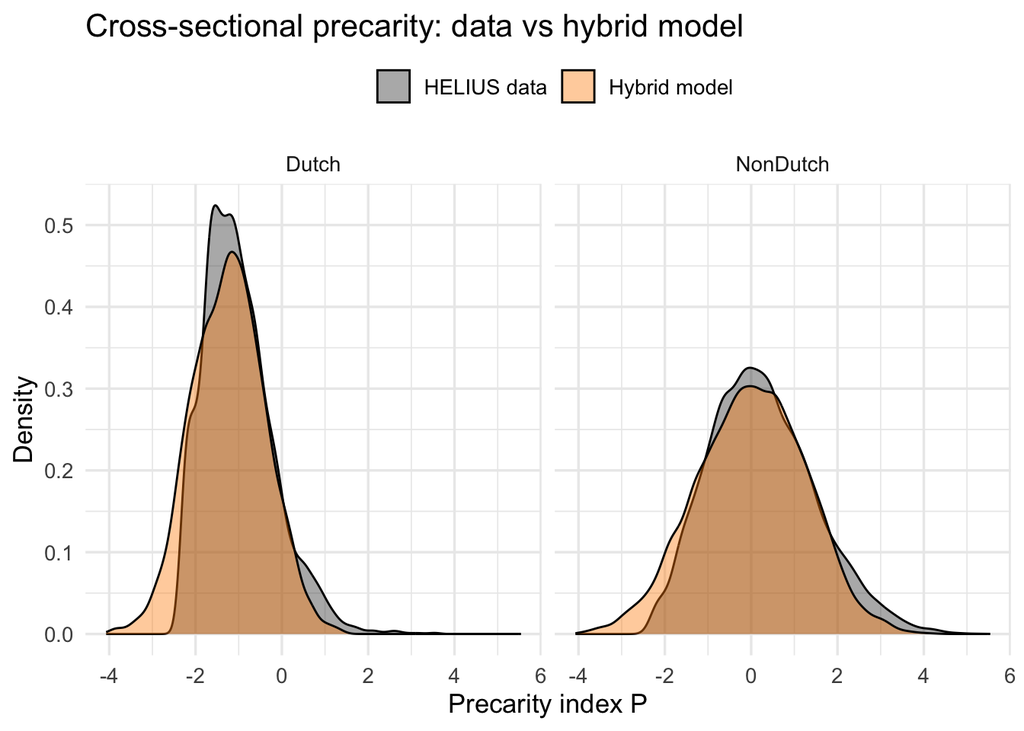

```r
  # (b) Distribution of P by group
  ggplot(snap_all, aes(x = P, fill = source)) +
    geom_density(alpha = 0.4) +
    facet_wrap(~ group) +
    scale_fill_manual(values = c("HELIUS data" = "grey20",
                                 "Hybrid model" = "darkorange")) +
    labs(
      title = "Cross-sectional precarity: data vs hybrid model",
      x = "Precarity index P",
      y = "Density",
      fill = ""
    ) +
    theme_minimal(base_size = 13) +
    theme(legend.position = "top")
```

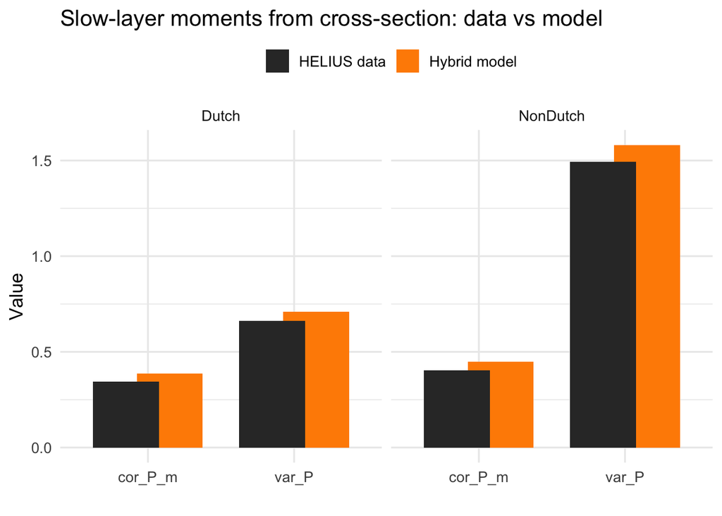

```r
  # (c) Correlation + variance summary from the cross-sections
  sim_targets <- snap_sim %>%
    group_by(group) %>%
    summarise(
      cor_P_m = cor(P, m),
      var_P   = var(P),
      .groups = "drop"
    ) %>%
    mutate(source = "Hybrid model")

  data_targets_short <- data_targets %>%
    select(group, cor_P_m, var_P) %>%
    mutate(source = "HELIUS data")

  targets_long <- bind_rows(sim_targets, data_targets_short) %>%
    tidyr::pivot_longer(
      cols      = c(cor_P_m, var_P),
      names_to  = "stat",
      values_to = "value"
    )

  ggplot(targets_long,
         aes(x = stat, y = value, fill = source)) +
    geom_col(position = position_dodge(width = 0.6)) +
    facet_wrap(~ group) +
    scale_fill_manual(values = c("HELIUS data" = "grey20",
                                 "Hybrid model" = "darkorange")) +
    labs(
      title = "Slow-layer moments from cross-section: data vs model",
      x = "",
      y = "Value",
      fill = ""
    ) +
    theme_minimal(base_size = 13) +
    theme(legend.position = "top")
```